# Methods for Data Science: Course Work 1

```python
import numpy as np
import matplotlib.pyplot as plt
import pandas as pd
from collections import defaultdict
import seaborn as sns
```

## Task 1: Regression (50 marks)

## 1.1 Linear regression (8 marks)

We are given an engineering dataset about different airfoils with various different mechanical features. These airfoils and features are associated with a sound pressure level. Each row represents a sample of an airfoil with 7 different features. Our goal is to be able to predict $\textbf{sound pressure}$ from the other 6 variables. To do so we will explore different regression models namely: Linear, Lasso, Elastic Net and kNN regression.

### 1.1.1

In this task, we will build a linear regression model to predict 'Sound Pressure', and so we will consider the linear regression problem of the form:

$$\textbf{y} = \textbf{X}\beta + \beta_0 + \boldsymbol\epsilon,$$

where $X \in \mathbb{R}^{N \times D}$, $y \in \mathbb{R}^N$ and $\boldsymbol\epsilon \sim N(0, \sigma^2 I)$. $\beta, \beta_0 \in \mathbb{R}^D $ are the parameters of interest that we seek to compute.

We will train the model on the $\textit{airfoil_noise_samples.csv}$ data considering the loss/cost function:

$$L(\beta) = \frac{1}{2N} ||\textbf{y} - \textbf{X} \beta -\beta _ 0||^2.$$

We want to minimise this loss function with respect to $\beta$, i.e. we want to solve

$$ \min_{\beta} \frac{1}{2N}| \textbf{y} - \textbf{X}\beta - \beta_0||^2.$$

We are able to follow the method in the notes since the only difference is our factor of $\frac{1}{2}$ and therefore find that $\hat{\beta} = (X^T X)^{-1}X^T y.$

Before we implement our linear regression model, we will import and prepare our dataset.

```python
# load airfoil_noise_samples data into a Pandas DataFrame using the read_csv function
airfoil_train = pd.read_csv('airfoil_noise_samples.csv')
```

```python
# check for any NA value
airfoil_train.isnull().values.any()
```

```
False
```

```python
# visualise our data
airfoil_train
```

|  | Frequency | Angle | Displacement | Chord length | Velocity | Thickness | Sound Pressure |
| --- | --- | --- | --- | --- | --- | --- | --- |
| 0 | 2175.611424 | 15.138865 | 21.075119 | 0.088194 | 66.764401 | 0.044771 | 122.365215 |
| 1 | 2962.923620 | 13.400893 | 13.200889 | 0.048462 | 78.221903 | 0.011041 | 129.296236 |
| 2 | 4430.810843 | 2.164599 | 13.959536 | 0.226743 | 57.053201 | 0.011499 | 121.827380 |
| 3 | 4939.695645 | 13.857682 | 18.203793 | 0.021705 | 23.896377 | 0.021475 | 114.998132 |
| 4 | 2193.979785 | 9.298757 | 11.007713 | 0.052737 | 38.917034 | 0.001741 | 125.639641 |
| ... | ... | ... | ... | ... | ... | ... | ... |
| 3885 | 3905.607276 | 9.799786 | 11.765429 | 0.028704 | 67.798053 | 0.004488 | 125.085653 |
| 3886 | 64.227331 | 2.707020 | 14.811376 | 0.235426 | 31.178047 | 0.001760 | 123.172927 |
| 3887 | 3284.747651 | 0.569689 | 0.340812 | 0.040439 | 49.229545 | 0.002682 | 134.214100 |
| 3888 | 5335.315242 | 5.525639 | 15.952651 | 0.197330 | 31.902680 | 0.008405 | 116.550551 |
| 3889 | 1334.882117 | 8.276053 | 14.560548 | 0.134638 | 63.902501 | 0.023547 | 123.960690 |

3890 rows × 7 columns

```python
# create our input variable X and output variable y
airfoil_train_array = airfoil_train.to_numpy() # convert to numpy array so we can use numpy functions

# get mean and standard deviation to standardise datasets
af_mean = np.mean(airfoil_train_array[:,:-1], axis=0)
af_std = np.std(airfoil_train_array[:,:-1], axis=0)

# slice out the target and predictor variables and standardise predictor variables
y11_train = airfoil_train_array[:,-1]
X11_train = (airfoil_train_array[:,:-1] - af_mean)/af_std
```

Now we have prepared our data by separating it into predictors and target variables we can implement our least squares estimate,

$$\hat{\beta} = (X^T X)^{-1}X^T y.$$

However, we will modify our original linear regression model by adding an intercept parameter $\beta_0$ so we end up with,

$$\textbf{y} = \textbf{X}_\text{aug} \boldsymbol\beta_\text{aug} + \boldsymbol\epsilon, $$

where $\boldsymbol\beta_\text{aug} = [\beta_0, \boldsymbol\beta]^T$ and $\textbf{X}_\text{aug} = [\mathbb{1}, \textbf{X}]^T.$ By including the intercept term we force our line to not have to pass through the origin, meaning that $Y$ doesn't necessarily have an expectation of zero and that the estimates of the other parameters are not biased, ensuring our residual terms have zero mean.

This modification still results in the same least squares estimate which we now implement in `ls_estimate`.

```python
def ls_estimate(X, y):
    """
    Returns least squares estimate and augmented X matrix

    Args:
        X: (N x D) matrix of training inputs
        y: (N x 1) vector of training targets/observations
    Returns:
        1. (D+1 x 1) least squares parameters
        2. (N x D+1) augmented X matrix
    """

    N, D = X.shape # obtain dimensions of training input matrix
    X_aug = np.hstack([np.ones((N,1)), X]) # augmented training inputs of size (N x D+1)

    beta_ml = np.linalg.solve(X_aug.T @ X_aug, X_aug.T @ y) # calculate beta using formula from above

    return beta_ml, X_aug
```

Now that we have calculated our least squares estimate we can use it to form predictions in a function `linear_prediction`.

```python
def linear_prediction(X, beta):

    """
    Args:
        X: (N x D) matrix of inputs
        beta: (D x 1) vector of parameters
    Returns:
        prediction: (N x 1) vector prediction of f(X)
    """

    prediction = X @ beta # calculate prediction by matrix multiplication

    return prediction
```

Now we have computed our least squares estimate and formed predictions we want to evaluate how well our model is, we can do so by comparing the MSE and $R^2$ scores. The MSE measures the average squared difference between observed and predicted values. Therefore, to determine how close our regression line is to our data let us calculate the mean squared errors (MSE). The labels of the test set will be called $y$ and the predictions on the test data $\hat{y}$.

$$\text{MSE}(y, \hat{y}) = \frac{1}{N} \sum_{i=1}^{N} (y_i - \hat{y}_i)^2.$$

```python
def MSE(y_test, y_pred):

    """
    Args:
        y_test: (K x 1) vector of test values of target variable
        y_pred: (K x 1) vector of predicted target variable from maximum likelihood estimator
    Returns:
        MSE: mean squared error of test and prediction
    """

    return 1/len(y_pred) * np.sum((y_test - y_pred)**2)
```

The next measure is the $R^2$ score which describes the proportion of variation in the deoendent variable that is predictable from the independent variable. Therefore, to determine how well the predictions are, let us determine the $R^2$ score. The labels of the test set will be called $y$ and the predictions on the test data $\hat{y}$. $$ R^2(y, \hat{y}) = 1 - \frac{\sum_{i=1}^n (y_i - \hat{y}_i)^2}{\sum_{i=1}^n (y_i - \bar{y})^2} \, , $$ where $\bar{y} = \frac{1}{n} \sum_{i=1}^n y_i$.

```python
def r2_score(y_test, y_pred):

    """
    Args:
        y_test: (K x 1) vector of test values of target variable
        y_pred: (K x 1) vector of predicted target variable from maximum likelihood estimator
    Returns:
        R^2: R^2 score of test and prediction
    """

    numerator = np.sum((y_test - y_pred)**2) # use np.sum to caluclate sum of difference between elements of vector
    y_avg = np.mean(y_test) # use np.mean to find average of elements of y_test
    denominator = np.sum((y_test - y_avg)**2) # use np.sum to caluclate sum of difference between elements of vector

    return 1 - numerator/denominator
```

Now we have created functions to measure the performance of our model we can finally do some analysis. Let us first compute our $\beta$ and $\beta_0$ parameters from `ls_estimate` and visualise them.

```python
beta11_train, X11_train_aug = ls_estimate(X11_train, y11_train)
df_beta = pd.DataFrame(beta11_train, columns=['Linear Regression - Beta Parameters'], index=[[r'$\beta_%s$' %i for i in range(7)]])
df_beta
```

|  | Linear Regression - Beta Parameters |
| --- | --- |
| $\beta_0$ | 123.970283 |
| $\beta_1$ | -3.575497 |
| $\beta_2$ | 0.834478 |
| $\beta_3$ | -3.928647 |
| $\beta_4$ | -0.078334 |
| $\beta_5$ | 1.724957 |
| $\beta_6$ | -0.013563 |

We see that our intercept $\beta_0$ has a value of 123.970283 which means when all variables have a coefficients of zero, the average sound pressure level is 123.970283 which does not make sense to interpret in this context. Furthermore, we see that $\beta_1, \beta_3, \beta_4 \ \text{and} \ \beta_6$ have a negative association with our target variable and that $\beta_2 \ \text{and} \ \beta_5$ have a positive association with our target variable.

Now we have obtained and interpreted our model parameters we can now form predictions $\hat{y}$ from $\hat{\beta}$ and compare it to $y$. We can then calculate the in-sample MSE and $R^2$ score on the sample dataset using our functions `MSE` and `r2_score` to evaluate our model on the sample dataset.

```python
y11_pred_train = linear_prediction(X11_train_aug, beta11_train)
linear_regression_mse_train = MSE(y11_train, y11_pred_train)
linear_regression_r2_train = r2_score(y11_train, y11_pred_train)
print('Linear Regression: MSE of in-samples:', linear_regression_mse_train)
print('Linear Regression: R^2 of in-samples:', linear_regression_r2_train)
```

```
Linear Regression: MSE of in-samples: 1.8755566396402008
Linear Regression: R^2 of in-samples: 0.9177343977263077
```

### 1.1.2

We, have computed our model parameter estimates and obtained the MSE and $R^2$ score on our sample dataset, but now we would like to compare it to a test dataset to see how well our model performs.

First, we will import our test dataset and prepare it.

```python
# load airfoil_noise_samples data into a Pandas DataFrame using the read_csv function and visualise
airfoil_test = pd.read_csv('airfoil_noise_test.csv')
airfoil_test
```

|  | Frequency | Angle | Displacement | Chord length | Velocity | Thickness | Sound Pressure |
| --- | --- | --- | --- | --- | --- | --- | --- |
| 0 | 1143.654418 | 12.783087 | 15.277127 | 0.110389 | 46.089548 | 0.024076 | 125.332111 |
| 1 | 619.208992 | 4.460285 | 16.198696 | 0.284357 | 36.728360 | 0.004000 | 122.801183 |
| 2 | 646.114737 | 2.521952 | 7.533605 | 0.072292 | 59.498237 | 0.003590 | 129.361188 |
| 3 | 1246.777461 | 8.438129 | 12.396435 | 0.034411 | 47.557277 | 0.002407 | 125.656263 |
| 4 | 286.200927 | 12.238350 | 20.877161 | 0.082437 | 72.786590 | 0.036883 | 124.241736 |
| ... | ... | ... | ... | ... | ... | ... | ... |
| 968 | 661.642089 | 16.204397 | 17.346930 | 0.033384 | 72.142746 | 0.005794 | 126.250349 |
| 969 | 670.716708 | 2.445070 | 11.610920 | 0.248936 | 24.644222 | 0.002454 | 122.612541 |
| 970 | 1332.771483 | 11.083461 | 15.955273 | 0.104500 | 68.543729 | 0.008514 | 125.849598 |
| 971 | 2718.763522 | 2.928932 | 3.939470 | 0.133589 | 73.328072 | 0.000757 | 134.637862 |
| 972 | 1959.014904 | 10.730063 | 14.775275 | 0.127446 | 47.155652 | 0.009146 | 123.578108 |

973 rows × 7 columns

```python
# convert to numpy array for slicing
airfoil_test_array = airfoil_test.to_numpy()
# slice out our target and predictor variables
y11_test = airfoil_test_array[:,-1]
X11_test = (airfoil_test_array[:,:-1]-af_mean)/af_std
```

```python
# augmented training inputs (N x D+1)
X11_test_aug = np.hstack([np.ones((X11_test.shape[0],1)), X11_test])

# predict target variables with the maximum likelihood/least squares estimate we found on our test data
y11_pred_test = linear_prediction(X11_test_aug, beta11_train)
```

We have prepared out test data accordingly. Now we can calculate the out-of-sample MSE and $R^2$ score of the test set using our functions `MSE` and `r2_score`.

```python
linear_regression_mse_test = MSE(y11_test, y11_pred_test)
linear_regression_r2_test = r2_score(y11_test, y11_pred_test)
print('Linear Regression: MSE of out-of-samples:', linear_regression_mse_test)
print('Linear Regression: R^2 of out-of-samples:', linear_regression_r2_test)
```

```
Linear Regression: MSE of out-of-samples: 1.9843895771191522
Linear Regression: R^2 of out-of-samples: 0.9083172459581625
```

Now we have the MSE and $R^2$ scores for the in and out-samples we can compare our findings. We see that for the MSE we have scores of 1.8755566396402008 and 1.9843895771191522 for the in-sample and out-sample respectively. This behaviour is expected since when building a Linear regression model we aim to minimise the mean squared errors and therefore the MSE on the training data should be less than the test since the MSE on the test was calculated on data unseen during the minimisation. It's worth noting the fractional difference in score between the in-samples and out-samples which suggests our model is somewhat sufficient. The difference in MSE could suggest that we have our model overfits the data however further analysis would be reuwired to make a conclusion.

Additionally we obtain $R^2$ scores of 0.9177343977263077 and 0.9083172459581625 for the in-sample and out-sample respectively so our model provides a better fit to the in-sample than the out-sample; a behaviour we expect. This is because when computing the $R^2$ score on the training set the measure tells us how much of the variance within our sample is explained by our model, however, computing the score on the test data tells us something about the predictive quality of our model. It's worth noting the fractional difference in score between the in-samples and out-samples which suggests our model is somewhat sufficient. The small difference in $R^2$ score suggests a well fitted model that does not exhibit over-fitted behaviour

## 1.2 Lasso regression (12 marks)

### 1.2.1

$$ L_{\text{LASSO}}(\beta) = \frac{1}{2N} ||\textbf{y} - \textbf{X} \beta - \beta_0||^2 + \lambda ||\beta||_{1},$$

via gradient descent and learning rate $l_r \propto 1/N_{\text{iterations}}$ to see if we can improve upon our Linear regression model. The 1-norm above does not include the $\beta_0$ term since we do not want to shrink the intercept. In order to minimise the loss function we must solve

$$ \min_{\beta}L_{\text{LASSO}}(\beta) = \min_{\beta} \frac{1}{2N} ||\textbf{y} - \textbf{X}\beta - \beta_0||^2 + \lambda ||\beta||_{1},$$

and to do so we will make use of gradient descent. Gradient descent is a widely used optimization technique that iteratively adjusts the parameters of a function in the direction of the negative gradient to minimize its value. Since gradient descent relies on the gradient of the object to be optimised and that the the derivative of the loss function is not continuous at $x=0$ we will set the derivative to be $0$ at $x=0$. Differentiating the loss function with respect to $\beta$ and $\beta_0$ we obtain:

$$ \frac{\partial L}{\partial \beta} = \frac{1}{N} \textbf{X}^T(\textbf{X}\beta + \beta_0 - \textbf{y}) + \lambda \cdot \text{sgn}(\beta),$$

and

$$\frac{\partial L}{\partial \beta_0} = \frac{1}{N} \sum_{i=1}^{N} (\hat{y}_i - y_i).$$

We will then employ 5-fold cross-validation to tune and find the optimal value of of our hyper-parameter $\lambda$ and use the average MSE over the folds as our measure.

k-fold cross-validation is a statistical method to tune a hyper-parameter it works by splitting our data into k-subsets of approximately equal size. The model is trained on k-1 of these subsets and validated on the remaining subset, this process is repeated k times. We measure the performance on each fold and obtain an average score typically MSE for regression and accuracy for classification. We perform this technique over a range of our hyper-paramters and then choosse the value of our hyper-parameter that optimises the score.

Before we start we will prepare our dataset by standardising our predictor variables and permuting the rows of our dataset. We standardise our data in Lasso regression to ensure that our penalty term $\lambda$ is equally applied to all our predictor variables since Lasso enforeces a penalty on the size of the coefficients of our predictor variables. Also, we permute the rows of our dataset in case there's an underlying structure/pattern to our dataset which would affect our cross-validation.

```python
# create predictor and target variables by slicing and standardising our predictor variables
y12_train = airfoil_train_array[:,-1]
X12_train = (airfoil_train_array[:,:-1] - af_mean)/af_std

# permute the rows of our data using np.random.permutation using the ouput as the new indexes
np.random.seed(1734654351)
p = np.random.permutation(len(y12_train))
X12_train_perm = X12_train[p]
y12_train_perm = y12_train[p]

# create list of 5-index arrays corresponding to indices of the 5-folds
folds_indexes_5 = np.array_split(np.arange(len(y12_train_perm)), 5)
```

Now our data is prepared and we have derived the gradients of our loss function we will implement gradient descent to minimise our Lasso loss function using the cost function as our convergence criterion. We set a learning rate of $10/{N_{\text{iterations}}}$ as this provided the best estimate after playing with the number of iterations and stop criterion.

```python
def lasso_descent(X, y, lambd, num_iterations=5000, print_outcome=False, stop_criterion=0.0001):
    """
    Returns beta and beta0 estimates by minimising Lasso loss function via gradient descent

    Args:
        X: (N x D) matrix of training inputs
        y: (N x 1) vector of training ouputs
        lambd: float, penalty parameter (lambda)
        num_iterations: int, number of iterations our gradient descent will run for
        print_outcome: boolean, toggle to print value of cost function at ith iteration
        stop_criterion: float, stop criterion for our gradient descent

    Returns:
        beta: (D x 1) vector of computed parameters
        beta0: scalar value of intercept (beta0)
    """
    N, D = X.shape # obtain shape of training inputs
    beta = np.zeros(D) # initialise values of beta to 0
    beta0 = np.zeros(1) # initialise value of beta0 to 0
    prev_cost = np.inf # store cost of previous iteration for stopping criterion

    for i in range(num_iterations):

        # calculate gradients
        y_pred = X @ beta + beta0
        dbeta = 1/N * X.T@(y_pred - y) + lambd * np.sign(beta)
        dbeta0 = (y_pred - y).mean()

        # update parameter after each iteration of gradient descent with learning rate 10/(i+1)
        beta = beta - 10/(i+1) * dbeta
        beta0 = beta0 - 10/(i+1) * dbeta0

        # calcluate cost and size of dbeta and print cost every 1000th iteration to check convergence
        if i % 1000 == 0 and print_outcome == True:
            cost = 1/(2*N) * sum((y - y_pred)**2) + lambd * np.sum(abs(beta))
            print("Iteration:{}, cost: {:.4f}".format(i, cost))
            print(np.linalg.norm(dbeta))

            # stopping criterion based on cost function
            if abs(prev_cost - cost) < stop_criterion * prev_cost:
                return beta, beta0
            prev_cost = cost

    return beta, beta0
```

Before we implement our cross-validation function we will define `lasso_score` which will compute the MSE for every fold in our cross-validation.

```python
def lasso_score(X_train, y_train, X_test, y_test, lambd):
    """
    Computes MSE of prediction on test data from parameters computed from training data for Lasso regression

    Args:
        X_train: array of training data input
        y_train: vector of training data output
        X_test: array of test data input
        y_test: vector of test data output
        lambd: scalar, penalty (lambda)

    Returns:
        MSE: MSE of prediction of test data
    """
    # compute beta and beta0 from X_train, y_train and lambd using Lasso descent
    beta, beta0 = lasso_descent(X_train, y_train, lambd, num_iterations=5000, print_outcome=False)

    # form prediction using calculated beta, beta0 and X_test
    y_pred = X_test @ beta + beta0

    return MSE(y_pred, y_test)
```

Now we have defined our `lasso_score` function for cross-validation we can now implement our 5-fold cross-validation for our hyper-parameter $\lambda$.

```python
def lasso_cross_validation_score(X_train, y_train, folds, k):
    """
    Perform T-fold cross-validation on a value of k

    Args:
        X_train: array of training input
        y_train: vector of training output
        folds: array where each row contains indices of fold
        k: hyper-parameter of Lasso regression

    Returns:
        Average MSE score over folds
    """
    # empty list to store scores
    scores = []
    for i in range(len(folds)):
        # get indices of validation set
        val_indexes = folds[i]
        # get indices of training set by subtracting val_indexes indices
        train_indexes = list(set(range(y_train.shape[0])) - set(val_indexes))

        # get training set
        X_train_i = X_train[train_indexes, :]
        y_train_i = y_train[train_indexes]

        # get validation set
        X_val_i = X_train[val_indexes, :]
        y_val_i = y_train[val_indexes]

        # calcualte score (MSE) of set
        score_i = lasso_score(X_train_i, y_train_i, X_val_i, y_val_i, k)
        scores.append(score_i)

    # Returns the average score
    return sum(scores) / len(scores)
```

Now we have defined a function for cross-validation `lasso_cross_validation_score`, let us create a function that scans a range of values of $\lambda$ and select the $\lambda$ which provides the lowest average MSE score.

```python
def lasso_choose_best_k(X_train, y_train, folds, k_range):
    """
    Provided a list of hyper-parameters (k_range), selects the parameter, k, providing the lowest MSE score

    Args:
        X_train: array of training input
        y_train: vector of training output
        folds: array where each row contains indices of fold
        k_range: list of values of k to test

    Returns:
        k_range[best_k_index]: best k which provides lowest MSE
        Plot of k_range against average MSE
    """
    # initialise empty array to store scores
    k_scores = np.zeros((len(k_range),))
    for i, k in enumerate(k_range):
        # calculate score for each k and fold
        k_scores[i] = lasso_cross_validation_score(X_train, y_train, folds, k)
        # print ith parameter and corresponding score
        print(f'CV_ACC@k={k}: {k_scores[i]}')

    # choose best k by finding index that provides the lowest MSE
    best_k_index = np.argmin(k_scores)

    # plot k_range(Lambda Values) against Average MSE Score
    plt.figure(figsize=(10,6))
    plt.plot(k_range, k_scores)
    plt.xlabel('Lambda Values')
    plt.ylabel('Average MSE Score')
    plt.title('Average MSE For Corresponding Lambda Values in Cross-validation')
    plt.ticklabel_format(style='plain')
    plt.plot(k_range[best_k_index], k_scores[best_k_index], 'r*')
    plt.show()

    return k_range[best_k_index]
```

We will now call our function `lasso_choose_best_k` scanning values of lambda in $[0, 0.02]$ and obtain our optimal $\lambda$ and corresponding $\beta$ and $\beta_0$ parameters.

```
CV_ACC@k=0.0: 1.886274493621682
CV_ACC@k=0.0006896551724137932: 1.886115660678416
CV_ACC@k=0.0013793103448275863: 1.8859693285815808
CV_ACC@k=0.0020689655172413794: 1.8858497637099618
CV_ACC@k=0.0027586206896551726: 1.8857474103470018
CV_ACC@k=0.003448275862068966: 1.8856572892335515
CV_ACC@k=0.004137931034482759: 1.885579409332934
CV_ACC@k=0.004827586206896552: 1.885513741029209
CV_ACC@k=0.005517241379310345: 1.8854536084152744
CV_ACC@k=0.0062068965517241385: 1.8854026793716034
CV_ACC@k=0.006896551724137932: 1.8853632939519787
CV_ACC@k=0.007586206896551725: 1.8853353709118181
CV_ACC@k=0.008275862068965517: 1.8853189500374943
CV_ACC@k=0.008965517241379312: 1.885313986988993
CV_ACC@k=0.009655172413793104: 1.8853205923205176
CV_ACC@k=0.010344827586206898: 1.885338720287263
CV_ACC@k=0.01103448275862069: 1.8853683419684966
CV_ACC@k=0.011724137931034483: 1.885409356125966
CV_ACC@k=0.012413793103448277: 1.885461979130693
CV_ACC@k=0.01310344827586207: 1.8855261676469222
CV_ACC@k=0.013793103448275864: 1.8856017518883479
CV_ACC@k=0.014482758620689656: 1.8856888319018439
CV_ACC@k=0.01517241379310345: 1.8857995058240067
CV_ACC@k=0.015862068965517243: 1.885957693961442
CV_ACC@k=0.016551724137931035: 1.8861378189615032
CV_ACC@k=0.017241379310344827: 1.8863408287657077
CV_ACC@k=0.017931034482758623: 1.8865470045326298
CV_ACC@k=0.018620689655172416: 1.8867704574510924
CV_ACC@k=0.019310344827586208: 1.887001603297892
CV_ACC@k=0.02: 1.8872406629338214
```

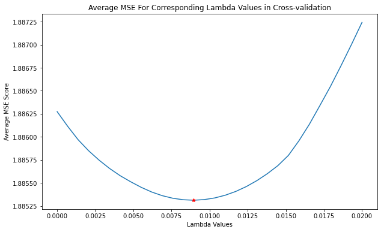

```
Optimal Lasso Lambda: 0.008965517241379312
```

```python
lambd_range = np.linspace(0,0.02,30)
lasso_best_k = lasso_choose_best_k(X12_train_perm, y12_train_perm, folds_indexes_5, lambd_range)

print('Optimal Lasso Lambda:', lasso_best_k)
```

```python
# train the Lasso regression model on the training data with optimal lambda value to obtain
# parameter estimates and visualise parameters
beta12, beta012 = lasso_descent(X12_train, y12_train, lasso_best_k)
df_beta_lasso = pd.DataFrame(np.insert(beta12, 0, beta012), columns=['Lasso Regression - Beta Parameters'], index=[[r'$\beta_%s$' %i for i in range(7)]])
df_beta_lasso
```

|  | Lasso Regression - Beta Parameters |
| --- | --- |
| $\beta_0$ | 123.970283 |
| $\beta_1$ | -3.564891 |
| $\beta_2$ | 0.777168 |
| $\beta_3$ | -3.885225 |
| $\beta_4$ | -0.099825 |
| $\beta_5$ | 1.715452 |
| $\beta_6$ | -0.000025 |

### 1.2.2

Now we have found the optimal value of $\lambda$ using 5-fold cross-validation let us choose one training/validation split and visualise the parameters $\beta$ as a function of $\lambda$. First let's randomly choose a training/validation split.

```python
# choose random integer from 1 to 5 corresponding to one of our five splits
i = np.random.randint(5)
val_indexes = folds_indexes_5[i]
train_indexes = list(set(range(y12_train_perm.shape[0])) - set(val_indexes))

# create training split
X_train_i = X12_train_perm[train_indexes, :]
y_train_i = y12_train_perm[train_indexes]

# create validation split
X_val_i = X12_train_perm[val_indexes, :]
y_val_i = y12_train_perm[val_indexes]
```

Now let us calculate the corresponding $\beta$ for each value of $\lambda$.

```python
lasso_lambd = np.linspace(0, 3, 50) # list of lambdas to calculate corresponding beta parameters
lambd122 = {} # empty dictionary to store beta parameters

# for loop over lambda values calculating beta and storing in dictionary
for lambd in lasso_lambd:
    beta, beta0 = lasso_descent(X_train_i, y_train_i, lambd)
    lambd122[lambd] = beta
```

Now we have our dictionary of $\lambda$ values with their corresponding $\beta$ value we can plot the penalty against the parameters and visualise the behaviour.

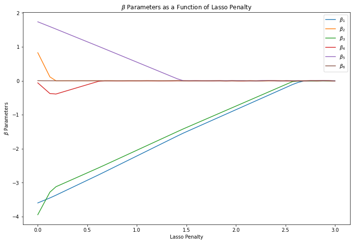

```python
plt.figure(figsize=(12,8))
for i in range(X_train_i.shape[1]):
    plt.plot(list(lambd122.keys()), [lambd122[lambd][i] for lambd in lambd122.keys()], label = (r"$\beta_{j}$".format(j=i+1)))

plt.xlabel("Lasso Penalty")
plt.ylabel(r"$\beta$ Parameters")
plt.title(r"$\beta$ Parameters as a Function of Lasso Penalty")
plt.legend()
plt.show()
```

We can see from the plot that as the penalty term, $\lambda$ increases the estimate $\beta$ coefficient become smaller with some shrinking to 0 as expected in Lasso regression. This results in a model with less variables and therefore reduced variance but increased bias. This relationship reflects the bias-variance tradeoff, that is: a lower value of $\lambda$ allow for more flexible models with lower bias but higher varaince compared to higher values of $\lambda$ that lead to simpler models with higher bias but lower variance. We can see that $\beta_6$ seems to be the first parameter to be shrunk to 0 followed by $\beta_2$ then $\beta_4$. Next to shrink to 0 is $\beta_5$ at around $\lambda =1.5$ then $\beta_3$ closely followed by $\beta_1$.

### 1.2.3

Finally we have implemented a way to find the optimal $\lambda$ hyper-parameter via 5-fold cross validation let us see how well it performs on the test dataset.

First let us define a function for predicting the target variable from Lasso regression.

```python
def lasso_predict(X, beta, beta0):
    """
    Args:
        X: (N x D) matrix of inputs
        beta: (D x 1) vector of parameters
    Returns:
        prediction: (N x 1) vector prediction of f(X)
    """
    N, d = X.shape # obtain shapes of inputs
    X_aug = np.hstack([np.ones((N,1)), X]) # augmented training inputs of size (N x D+1)

    beta = np.insert(beta, 0, beta0) # np.insert inserts beta0 to first element of beta
    y_pred = X_aug @ beta # prediction by matrix multiplying X_aug and beta

    return y_pred
```

Now we can prepare the test dataset and obtain our $\beta$ estimates and predictions.

```python
# prepare test dataset and standardise the predictor variables
y12_test = airfoil_test_array[:,-1]
#X12_test = standardise(airfoil_test_array[:,:-1])
X12_test = (airfoil_test_array[:,:-1] - af_mean)/af_std


# calculate predictions using our model on both the training and test data set
y12_train_pred = lasso_predict(X12_train, beta12, beta012)
y12_test_pred = lasso_predict(X12_test, beta12, beta012)
```

```python
print(f'Lasso Regression: MSE of in-samples', MSE(y12_train_pred, y12_train))
print(f'Lasso Regression: MSE of out-of-sample:', MSE(y12_test_pred, y12_test))
```

```
Lasso Regression: MSE of in-samples 1.8765238861257894
Lasso Regression: MSE of out-of-sample: 1.985431686192888
```

```python
print(f'Lasso Regression: R2 score of in-samples:', r2_score(y12_train_pred, y12_train))
print(f'Lasso Regression: R2 score of out-of-samples:', r2_score(y12_test_pred, y12_test))
```

```
Lasso Regression: R2 score of in-samples: 0.9095321379801453
Lasso Regression: R2 score of out-of-samples: 0.8985542686610766
```

Now we can discuss our models in the case of our optimal $\lambda$ (Lasso regression) and $\lambda =0$ (Linear regression). Let us create a table containg the different scores to help visualise.

```python
# create list of scores for DataFrame
data123 = [[linear_regression_mse_train, linear_regression_r2_train], [linear_regression_mse_test, linear_regression_r2_test], [MSE(y12_train_pred, y12_train),r2_score(y12_train_pred, y12_train)], [MSE(y12_test_pred, y12_test), r2_score(y12_test_pred, y12_test) ]]
# create DataFrame of scores
df123 = pd.DataFrame(data123, columns=['MSE', 'R^2'], index = ['Linear Regression: in-sample', 'Linear Regression: out-of-sample', 'Lasso Regression: in-sample', 'Lasso Regression: out-of-sample'])
df123
```

|  | MSE | R^2 |
| --- | --- | --- |
| Linear Regression: in-sample | 1.875557 | 0.917734 |
| Linear Regression: out-of-sample | 1.984390 | 0.908317 |
| Lasso Regression: in-sample | 1.876524 | 0.909532 |
| Lasso Regression: out-of-sample | 1.985432 | 0.898554 |

We see that our MSE increases on the test data in Lasso regression which could suggest over-fitting, however, further analysis would be required to make any conclusion. The $R^2$ score sightly decreases on the test data but not a lot which suggests a well-fitted model.

We can see that on our training dataset our Linear regression model exhibits both a lower MSE and greater $R^2$ score compared to that of Lasso regression. On the test dataset our Linear regression model performs better in terms of MSE and $R^2$ score however the differences are fractional.

These behaviours are possibly not what we expected as in general we expect that the Lasso regression model would fit the data better: a possible reason for this is an inaccurate estimate of the $\beta$ parameters in Lasso regression due to the convergence in gradient descent. However this behaviour could be a result of the dataset and choice of seed. Additionally from our knowledge of the bias-variance tradeoff since we have a small $\lambda$ we have increased variance and decreased bias, this increased variance contributes to the MSE and therefore affects our MSE results.

## 1.3 Elastic Nets (20 marks)

### 1.3.1

We have built both a Linear and Lasso Regression model let us now explore Elastic Net regression. Elastic Net regression is a regularisation regression method that combines penalties of both Lasso and Ridge. In this task we will train an Elastic Net Linear Regression on $\textit{airfoil_noise_samples.csv}$ model with cost function:

$$L_{\text{EN}}(\beta) = \frac{1}{2N} ||\textbf{y} - \textbf{X}\beta - \beta_0||^2 + \lambda\left[\alpha ||\beta||_1 + (1-\alpha)||\beta||^2\right],$$

where $\lambda$ the strength of regularisation, learning rate $l_r \propto 1/N_{\text{iterations}}$ and $\alpha \in [0,1]$ which controls the strength of the regularisation.

Before we start we will prepare our data by standardising our predictor variables and shuffling the rows of our dataset for cross-validation in case there's an underlying structure.

```python
# set up our target and predictor variables by slicing and then standardising our predictor variable
y13_train = airfoil_train_array[:,-1]
X13_train = (airfoil_train_array[:,:-1] - af_mean)/af_std

# shuffle the rows by using indices obtained earlier from np.random.permutation
X13_train_perm = X13_train[p]
y13_train_perm = y13_train[p]
```

Our target and predictor variables are now ready. Next, we need to calculate our $\beta$ and $\beta_0$ parameters using gradient descent with learning rate $l_r \propto 1/N_{\text{iterations}}$. First we must differentiate the cost function with respect to $\beta$ and $\beta_0$ to obtain our gradients,

$$ \frac{\partial L}{\partial \beta} = \frac{1}{N} \textbf{X}^T (\textbf{X}\beta + \beta_0 - \textbf{y}) + \lambda \cdot \alpha \cdot \text{sgn}(\beta) + \lambda \cdot (1-\alpha) \cdot 2\beta, $$

and

$$ \frac{\partial L}{\partial \beta_0} = \frac{1}{N} \sum_{i=1}^{N} (\hat{y}_i - y_i),$$

where $\hat{y}_i = [\textbf{X}\beta + \beta_0]_i$. Now we have our gradients for gradient descent let us implement our scheme below in `elasnet_descent` with learning rate $10/N_{\text{iterations}}$.

```python
def elasnet_descent(X, y, lambd, alpha, num_iterations=5000, print_outcome=False, stop_criterion = 0.0001):
    """
    Returns beta and beta0 estimates by minimising Elastic Net loss function via gradient descent

    Args:
        X: (N x D) matrix of training inputs
        y: (N x 1) vector of training ouputs
        lambd: float, penalty parameter (lambda)
        alpha: float, coefficient controlling Lasso and Ridge penalty term
        num_iterations: int, number of iterations our gradient descent will run for
        print_outcome: boolean, toggle to print value of cost function at ith iteration
        stop_criterion: float, stop criterion for our gradient descent

    Returns:
        beta: (D x 1) vector of computed parameters
        beta0: scalar value of intercept (beta0)
    """
    N, D = X.shape # obtain shape of training inputs
    beta = np.zeros(D) # initialise values of beta to 0
    beta0 = np.zeros(1) # initialise value of beta0 to 0
    prev_cost = np.inf # store cost of previous iteration for stopping criterion

    for i in range(num_iterations):

        # calculate prediction and gradients
        y_pred = X @ beta + beta0
        dbeta = 1/N * X.T@(y_pred - y) + lambd * alpha *np.sign(beta) + lambd * (1-alpha) * 2 * beta
        dbeta0 = (y_pred - y).mean()

        # update parameter after each iteration of gradien descent with learning rate 10/(i+1)
        beta = beta - 10/(i+1) * dbeta
        beta0 = beta0 - 10/(i+1) * dbeta0

        # calculate cost and size of dbeta and print cost every 1000th iteration to check convergence
        if i % 1000 == 0 and print_outcome == True:
            cost = 1/(2*N) * sum((y - y_pred)**2) + lambd * np.sum(abs(beta))
            print("Iteration:{}, cost: {:.4f}".format(i, cost))
            print(np.linalg.norm(dbeta))

            # stopping criterion based on cost function
            if abs(prev_cost - cost) < stop_criterion * prev_cost:
                return beta, beta0
            prev_cost = cost

    return beta, beta0
```

```python
def elasnet_score(X_train, y_train, X_test, y_test, lambd, alpha):
    """
    Computes MSE of prediction on test data from parameters computed from training data for Elastic Net regression

    Args:
        X_train: array of training data input
        y_train: vector of training data output
        X_test: array of test data input
        y_test: array of test data output
        lambd: scalar, penalty (lambd)
        alpha: float, coefficient controlling Lasso and Ridge penalty term
    Returns:
        MSE: MSE of prediction of test data
    """
    beta, beta0 = elasnet_descent(X_train, y_train, lambd, alpha, num_iterations=5000, print_outcome=False)

    y_pred = X_test @ beta + beta0

    return MSE(y_pred, y_test)
```

### 1.3.2

Now that we have implemented gradient descent for Elastic Net regression we can now begin to conduct a grid search to find the optimal penalty hyper-parameter $\lambda$ for our Elastic Net model. We will use 5-fold cross-validation for fixed $\alpha \in \{0.1, 0.5, 0.9\}$

```python
def elasnet_cross_validation_score(X_train, y_train, folds, k, alpha):
    """
    Perform T-fold cross-validation on a value of k

    Args:
        X_train: array of training input
        y_train: vector of training output
        folds: array where each row contains indices of fold
        k: hyper-parameter of Elastic Net regression
        alpha: float, coefficient controlling Lasso and Ridge penalty term
    Returns:
        Average MSE score over folds
    """
    # empty list to store scores
    scores = []
    for i in range(len(folds)):
        # get indices of validation set
        val_indexes = folds[i]
        # get indices of training set by subtracting val_indexes indices
        train_indexes = list(set(range(y_train.shape[0])) - set(val_indexes))

        # get training set
        X_train_i = X_train[train_indexes, :]
        y_train_i = y_train[train_indexes]

        # get validation set
        X_val_i = X_train[val_indexes, :]
        y_val_i = y_train[val_indexes]

        # calculate score (MSE) of set
        score_i = elasnet_score(X_train_i, y_train_i, X_val_i, y_val_i, k, alpha)
        scores.append(score_i)

    # Return the average score
    return sum(scores) / len(scores)
```

```python
def elasnet_choose_best_k(X_train, y_train, folds, k_range, alpha):
    """
    Provided a list of hyper-parameters (k_range), selects the parameter, k, providing lowest MSE score

    Args:
        X_train: array of training input
        y_train: vector of training output
        folds: array where each row contains indices of fold
        k_range: lsit of values of k to test
        alpha: float, coefficient controlling Lasso and Ridge penalty term

    Returns:
        k_range[best_k_index]: best k which provides lowest MSE
        Plot of k_range against average MSE
    """
    # initialise empty array to store score
    k_scores = np.zeros((len(k_range),))
    for i, k in enumerate(k_range):
        # calculate score for each k and fold
        k_scores[i] = elasnet_cross_validation_score(X_train, y_train, folds, k, alpha)
        # print ith parameter and corresponding score
        print(f'CV_ACC@k={k} and a = {alpha}: {k_scores[i]}')

    # choose best k by finding index that provides the lowest MSE
    best_k_index = np.argmin(k_scores)

    # plot k_range (Lambda Values) against Average MSE score
    plt.figure(figsize=(10,6))
    plt.plot(k_range, k_scores)
    plt.xlabel('Lambda Values')
    plt.ylabel('MSE Score')
    plt.plot(k_range[best_k_index], k_scores[best_k_index], 'r*')
    plt.title('Average MSE for corresponding lambda values in cross-validation')
    plt.ticklabel_format(style='plain', useOffset=False)
    plt.show()

    return k_range[best_k_index]
```

Now we will call `elasnet_choose_best_k` to perform 5-fold cross-validation on each value of $\alpha \in \{0.1, 0.5, 0.9\}$.

```
CV_ACC@k=0.0 and a = 0.1: 1.886274493621682
CV_ACC@k=5.714285714285715e-05 and a = 0.1: 1.8862637305896253
CV_ACC@k=0.0001142857142857143 and a = 0.1: 1.8862553116699747
CV_ACC@k=0.00017142857142857145 and a = 0.1: 1.886249226128654
CV_ACC@k=0.0002285714285714286 and a = 0.1: 1.8862454632948427
CV_ACC@k=0.00028571428571428574 and a = 0.1: 1.8862440125605737
CV_ACC@k=0.0003428571428571429 and a = 0.1: 1.8862448633819393
CV_ACC@k=0.0004 and a = 0.1: 1.8862480052761197
CV_ACC@k=0.0004571428571428572 and a = 0.1: 1.8862534278236105
CV_ACC@k=0.0005142857142857143 and a = 0.1: 1.8862611206649789
CV_ACC@k=0.0005714285714285715 and a = 0.1: 1.8862710734953834
CV_ACC@k=0.0006285714285714286 and a = 0.1: 1.8862832760947832
CV_ACC@k=0.0006857142857142858 and a = 0.1: 1.8862977182771334
CV_ACC@k=0.000742857142857143 and a = 0.1: 1.8863143899267274
CV_ACC@k=0.0008 and a = 0.1: 1.8863343028936481
```

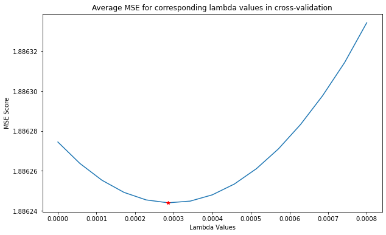

```
Optimal lambda for alpha = 0.1: 0.00028571428571428574
```

```python
elasnet_best_k1 = elasnet_choose_best_k(X13_train_perm, y13_train_perm, folds_indexes_5, np.linspace(0,0.0008,15), 0.1)

print('Optimal lambda for alpha = 0.1:', elasnet_best_k1)
```

```
CV_ACC@k=0.0 and a = 0.5: 1.886274493621682
CV_ACC@k=0.00010714285714285715 and a = 0.5: 1.8862522979309524
CV_ACC@k=0.0002142857142857143 and a = 0.5: 1.886233370018757
CV_ACC@k=0.00032142857142857147 and a = 0.5: 1.8862176944741655
CV_ACC@k=0.0004285714285714286 and a = 0.5: 1.886205255978823
CV_ACC@k=0.0005357142857142857 and a = 0.5: 1.8861960393107684
CV_ACC@k=0.0006428571428571429 and a = 0.5: 1.8861900293404503
CV_ACC@k=0.00075 and a = 0.5: 1.8861872110311801
CV_ACC@k=0.0008571428571428572 and a = 0.5: 1.886187569437516
CV_ACC@k=0.0009642857142857144 and a = 0.5: 1.886191089707238
CV_ACC@k=0.0010714285714285715 and a = 0.5: 1.886200683241188
CV_ACC@k=0.0011785714285714286 and a = 0.5: 1.8862151388948267
CV_ACC@k=0.0012857142857142859 and a = 0.5: 1.886232699725373
CV_ACC@k=0.001392857142857143 and a = 0.5: 1.886253352513804
CV_ACC@k=0.0015 and a = 0.5: 1.8862770792894927
```

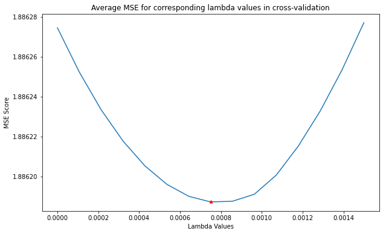

```
Optimal lambda for alpha = 0.5: 0.00075
```

```python
elasnet_best_k2 = elasnet_choose_best_k(X13_train_perm, y13_train_perm, folds_indexes_5, np.linspace(0,0.0015,15), 0.5)

print('Optimal lambda for alpha = 0.5:', elasnet_best_k2)
```

```
CV_ACC@k=0.0 and a = 0.9: 1.886274493621682
CV_ACC@k=0.00036842105263157896 and a = 0.9: 1.8861911414433241
CV_ACC@k=0.0007368421052631579 and a = 0.9: 1.8861149569200388
CV_ACC@k=0.0011052631578947368 and a = 0.9: 1.8860459190479322
CV_ACC@k=0.0014736842105263158 and a = 0.9: 1.8859862100168647
CV_ACC@k=0.001842105263157895 and a = 0.9: 1.885942805518876
CV_ACC@k=0.0022105263157894735 and a = 0.9: 1.8859063956051785
CV_ACC@k=0.0025789473684210526 and a = 0.9: 1.8858769590135107
CV_ACC@k=0.0029473684210526317 and a = 0.9: 1.8858544574998668
CV_ACC@k=0.0033157894736842108 and a = 0.9: 1.88583891229838
CV_ACC@k=0.00368421052631579 and a = 0.9: 1.8858302712070372
CV_ACC@k=0.0040526315789473685 and a = 0.9: 1.8858284953036697
CV_ACC@k=0.004421052631578947 and a = 0.9: 1.8858336158513491
CV_ACC@k=0.004789473684210527 and a = 0.9: 1.8858456031345352
CV_ACC@k=0.005157894736842105 and a = 0.9: 1.885864366026891
CV_ACC@k=0.005526315789473685 and a = 0.9: 1.8858900036254673
CV_ACC@k=0.005894736842105263 and a = 0.9: 1.8859223999168848
CV_ACC@k=0.006263157894736842 and a = 0.9: 1.8859615266013072
CV_ACC@k=0.0066315789473684215 and a = 0.9: 1.8860074668802962
CV_ACC@k=0.007 and a = 0.9: 1.886056909198955
```

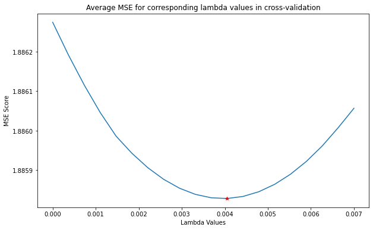

```
Optimal lambda for alpha = 0.9: 0.0040526315789473685
```

```python
elasnet_best_k3 = elasnet_choose_best_k(X13_train_perm, y13_train_perm, folds_indexes_5, np.linspace(0,0.007,20), 0.9)

print('Optimal lambda for alpha = 0.9:', elasnet_best_k3)
```

We have now found the optimal value of $\lambda$ for each value of $\alpha$ in our Elastic Net regression model, naturally we would like to see how well our models perform with these optimal hyper-paramters. To do so we will compute the MSE and $R^2$ scores for each model and compare the results. First let us implement a function to form predictions in our Elastic Net regression model in `elasnet_predict`.

```python
def elasnet_predict(X, beta, beta0):
    """
    Args:
        X: (N x D) matrix of inputs
        beta: (D x 1) vector of parameters
    Returns:
        y_pred: (N x 1) vector prediction of f(X)
    """
    # obtain shape of input
    N, d = X.shape
    # create augmented matrix of input
    X_aug = np.hstack([np.ones((N,1)), X])
    # insert beta0 to first element of beta
    beta = np.insert(beta, 0, beta0)
    # form prediction by matrix multiplication
    y_pred = X_aug @ beta

    return y_pred
```

Now we have implemented a predict function let us define functions for the MSE and $R^2$ below.

```python
def elasnet_mse(X_train, y_train, X_test, y_test, lambd, alpha):
    """
    Args:
        X_train: array of training input
        y_train: vector of training output
        X_test: array of test input
        y_test: vector of test output
        lambd: scalar, penalty parameter (lambda)
        alpha: float, coefficient controlling Lasso and Ridge penalty term

    Returns:
        MSE of Elastic Net regression model
    """
    # compute beta and beta0 from elasnet_descent
    beta, beta0 = elasnet_descent(X_train, y_train, lambd, alpha, num_iterations=5000, print_outcome=False)
    # compute prediction
    y_pred = elasnet_predict(X_test, beta, beta0)

    return MSE(y_pred, y_test) # return MSE of prediction on test data set
```

```python
def elasnet_r2(X_train, y_train, X_test, y_test, lambd, alpha):
    """
    Args:
        X_train: array of training input
        y_train: vector of training output
        X_test: array of test input
        y_test: vector of test output
        lambd: scalar, penalty parameter (lambda)
        alpha: float, coefficient controlling Lasso and Ridge penalty term

    Returns:
        R^2 score of Elastic Net regression model
    """
    # compute beta and beta0 from elasnet_descent
    beta, beta0 = elasnet_descent(X_train, y_train, lambd, alpha, num_iterations=5000, print_outcome=False)
    # compute prediction
    y_pred = elasnet_predict(X_test, beta, beta0)

    return r2_score(y_pred, y_test) # return R^2 score of prediction on test data set
```

Now we have functions to measure the performance of our model let us prepare our test dataset for evaluation.

```python
# prepare test dataset and standardise the predictor variables
y13_test = airfoil_test_array[:,-1]
X13_test = (airfoil_test_array[:,:-1] - af_mean)/af_std
```

```python
print(f"MSE for alpha = 0.1: ", elasnet_mse(X13_train, y13_train, X13_test, y13_test, elasnet_best_k1, 0.1))
print(f"MSE for alpha = 0.5: ", elasnet_mse(X13_train, y13_train, X13_test, y13_test, elasnet_best_k2, 0.5))
print(f"MSE for alpha = 0.9: ", elasnet_mse(X13_train, y13_train, X13_test, y13_test, elasnet_best_k3, 0.9))
```

```
MSE for alpha = 0.1:  1.9853706026600733
MSE for alpha = 0.5:  1.9858285823044284
MSE for alpha = 0.9:  1.9860612241868156
```

```python
print(f"R2 for alpha = 0.1: ", elasnet_r2(X13_train, y13_train, X13_test, y13_test, elasnet_best_k1, 0.1))
print(f"R2 for alpha = 0.5: ", elasnet_r2(X13_train, y13_train, X13_test, y13_test, elasnet_best_k2, 0.5))
print(f"R2 for alpha = 0.9: ", elasnet_r2(X13_train, y13_train, X13_test, y13_test, elasnet_best_k3, 0.9))
```

```
R2 for alpha = 0.1:  0.8992758996745922
R2 for alpha = 0.5:  0.8991461720415598
R2 for alpha = 0.9:  0.8987945459319051
```

We see that as $\alpha$ increases the MSE increases and the $R^2$ score decreases from these results we could conclude that $\alpha =0.1$ provides the best model. However, it is important to make sure this result follows the theory of Lasso, Ridge and Elastic Net regression.

## 1.3.3

We have performed 5-fold cross-validation over fixed $\alpha$ to find the optimal $\lambda$ penalty term. Now let us visualise the behaviour of our $\beta$ parameters with optimal $\lambda$ against our fixed $\alpha$. First let us create a dictionary to store the values of beta for each $\alpha$.

```python
elasnet_lambda = [elasnet_best_k1, elasnet_best_k2, elasnet_best_k3] # list of optimal lambda for each alpha for calculating beta
alpha = [0.1, 0.5, 0.9] # list of alpha
beta13 = {} # empty dictionary to store beta values

# for loop to calculate beta for each value of lambda and alpha
for lambd, a in zip(elasnet_lambda, alpha):
    beta13[a] = elasnet_descent(X13_train, y13_train, lambd, a)[0]
```

Now we have a dictionary of our $\beta$ values let us visualise the behaviour as $\alpha$ changes.

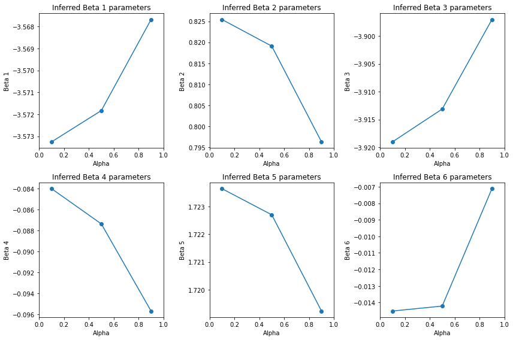

```python
# create 6 subplots for each beta
fig, axs = plt.subplots(nrows=2, ncols=3, figsize=(12, 8))
for i in range(6):
    row = i // 3
    col = i % 3

    # set labels of plot
    axs[row, col].set_ylabel(f'Beta {i+1}')
    axs[row, col].set_xlabel('Alpha')

    # empty list to store key and value of dictionary
    key_list = []
    value_list = []

    # loop over dictionary and and add value and key to list
    for key, value in beta13.items():
        key_list.append(key)
        if i < len(value):
            value_list.append(value[i])

    # create plot, set x-axis limit and set title
    axs[row, col].plot(key_list, value_list, 'o-')
    axs[row, col].set_xlim(left=0, right=1)
    axs[row, col].title.set_text(f'Inferred Beta {i+1} parameters')

plt.tight_layout()
plt.show()
```

We can see that as $\alpha$ increases we have that $\beta_1, \beta_3 \ \text{and} \ \beta_6$ increases but $\beta_2, \beta_4 \ \text{and} \ \beta_5$ decrease. On the case of $\alpha = 0$ the $\beta$ parameters should be the same as the parameters obtained in Ridge regression. For $\alpha =0.5$, the values of the $\beta$ parameters would reflect the parameters of an equally weighted regression model of Lasso and Ridge. Finally for $\alpha = 1$ the values of our $\beta$ parameter would be the same as obtained in Lasso regression.

## 1.4 kNN regression (10 marks)

### 1.4.1

The kNN algorithm can be used for both regression and classification problems. We have explored Linear, Lasso and Elastic Net regression which are extensions of each other. In this task we will train a k-Neareast Neighbour regression model on $\textit{airfoil_noise_samples.csv}$. Since the kNN algorithm is based on computing distances we will adopt the Euclidean distance, d, as our measure defined as: $$ d(\boldsymbol p, \boldsymbol q) = \sqrt{\sum_{i=1}^D{(q_i-p_i)^2}} \, , $$ where $\boldsymbol p$ and $\boldsymbol q$ are the two points in our $D$-dimensional Euclidean space. Then we will implement 5-fold cross-validation to find the optimal value of the hyper-parameter k.

First, let us prepare our data set by creating our predictor and target variables then standardising our predictor variable and permuting the rows for cross-validation.

```python
# set up our target and predictor variables by slicing and then standardising our predictor variable
y14_train = airfoil_train_array[:,-1]
X14_train = (airfoil_train_array[:,:-1] - af_mean)/af_std
```

```python
# permute the rows of our data using np.random.permutation using the ouput as the new indexes
X14_train_perm = X14_train[p]
y14_train_perm = y14_train[p]

# create list of 5-index arrays corresponding to indices of the 5-folds
folds_indexes_5 = np.array_split(np.arange(len(y14_train_perm)), 5)
```

Now we have prepared our predictor and target variables let us quickly implement our distance measure in `euclidean_distance`.

```python
def euclidean_distance(p, q):
    """
    Calculate Euclidean distance

    Args:
        p, q: arrays

    Returns:
        Euclidean distance between columns of the two arrays
    """
    return np.sqrt(np.sum((p-q)**2, axis=1))
```

Now our dataset has been prepared and our distance measure implemented let us now find the k nearest neighbours in our training test for every test data point using `k_neighbours` below.

```python
def k_neighbours(X_train, X_test, k, return_distance=False):
    """
    Given training and test dataset returns indices of k nearest neigbours

    Args:
        X_train: array of training input
        X_test: array of test input
        k: int, hyper-parameter for number of nearest neighbours
        return_distance: boolean whether to return k nearest distances

    Returns:
        dist: returns distance of k nearest neighbours
        neigh_ind: returns index of k nearest neighbours
    """
    # set number of neighbours to k and create empty lists to store distances and indices
    n_neighbours = k
    dist = []
    neigh_ind = []

    # compute distance from each point x_test in X_test to all points in X_train
    point_dist = [euclidean_distance(x_test, X_train) for x_test in X_test]

    # determine which k training points are closest to each test point
    for row in point_dist:
        # turn the row into an iterable object
        enum_neigh = enumerate(row)
        # sort neighbours according to distances with first column being indices
        sorted_neigh = sorted(enum_neigh, key=lambda x: x[1])[:k]

        # get indices and put into list ind_list
        ind_list = [tup[0] for tup in sorted_neigh]
        # get distance and put into list dist_list
        dist_list = [tup[1] for tup in sorted_neigh]
        dist.append(dist_list)
        neigh_ind.append(ind_list)

    # return distances together with indices of k nearest neighbours
    if return_distance:
        return np.array(dist), np.array(neigh_ind)

    return np.array(neigh_ind)
```

Now we have created a function `k_neighbours` which returns the k nearest neigbours to our test point we can now create a function `knn_predict` which predicts by taking the average $y$ value of the k nearest neighbours.

```python
def knn_predict(X_train, y_train, X_test, k):
    """
    Predict y values based on k nearest neighbours with equal weightings

    Args:
        X_train: array of training input
        y_train: vector of training output
        X_test: array of test input
        k: int, hyper-parameter determines how many closest neighbours to consider

    Returns:
        y_pred: vector of predictions
    """
    # each of the k neighbours contributes equally to the classification of any data point in X_test
    neighbours = k_neighbours(X_train, X_test, k)
    # compute mean over neighbours labels
    y_pred = np.array([np.mean(y_train[neighbour]) for neighbour in neighbours])

    return y_pred
```

Now we have created created functions to return the k nearest neughbours and predictions we would like to be able to evaluate how good our predictions are using the MSE as our measure which is done in `knn_score`.

```python
def knn_score(X_train, y_train, X_test, y_test, k):
    """
    Predict output y based on k nearest neighbours and return MSE of prediction

    Args:
        X_train: array of training input
        y_train: vector of training output
        X_test: array of test input
        y_test: vector of test output
        k: int, k nearest neighbour

    Returns:
        MSE of predictions compared to test data
    """
    # form prediction using knn_predict then calculate MSE of prediction
    y_pred = knn_predict(X_train, y_train, X_test, k)
    return MSE(y_test, y_pred)
```

Now that we have created functions that compute the k nearest neighbours, predictions and MSE scores, we can use a grid search with 5-fold cross-validation to find an optimal value of the the hyper-parameter $k$.

```python
def knn_cross_validation_score(X_train, y_train, folds, k):
    """
    Perform T-fold cross-validation on a value of k

    Args:
        X_train: array of training input
        y_train: vector of training output
        folds: array where each row contains indices of fold
        k: int, hyper-parameter of k nearest neighbours

    Returns:
        Average MSE score over folds
    """
    # empty list to store scores
    scores = []
    for i in range(len(folds)):
        # get indices of validation set
        val_indexes = folds[i]
        # get indices of training set by subtracting val_indexes indices
        train_indexes = list(set(range(y_train.shape[0])) - set(val_indexes))

        # get training set
        X_train_i = X_train[train_indexes, :]
        y_train_i = y_train[train_indexes]

        # get validation set
        X_val_i = X_train[val_indexes, :]
        y_val_i = y_train[val_indexes]

        # calculate score (MSE) of set
        score_i = knn_score(X_train_i, y_train_i, X_val_i, y_val_i, k)
        scores.append(score_i)

    # Return the average score
    return sum(scores) / len(scores)
```

Now let us create a function which calls `knn_cross_validation_score` over a range of our hyper-parameter k.

```python
def knn_choose_best_k(X_train, y_train, folds, k_range):
    """
    Provided a list of hyper-parameters (k_range), selects the parameter k, providing the lowest MSE score

    Args:
        X_train: array of training input
        y_train: vector of training outpu
        folds: array where each row contains indices of fold
        k_range: list of values of k to test

    Returns:
        k_range[best_k_index]: best k which provides lowest MSE
    """
    # initialise empty array to store scores
    k_scores = np.zeros((len(k_range),))
    for i, k in enumerate(k_range):
        # calculate score for each k and fold
        k_scores[i] = knn_cross_validation_score(X_train, y_train, folds, k)
        #print ith parameter and corresponding score
        print(f'CV_ACC@k={k}: {k_scores[i]}')

    # choose best k by finding index that provides lowest MSE
    best_k_index = np.argmin(k_scores)
    return k_range[best_k_index]
```

Now let us call `knn_choose_best_k` to find the optimal value of the hyper-parameter k.

```python
knn_best_k = knn_choose_best_k(X14_train_perm, y14_train_perm, folds_indexes_5, np.arange(1, 15))

print('knn_best_k:', knn_best_k)
```

```
CV_ACC@k=1: 5.212454915992254
CV_ACC@k=2: 3.7790288020096745
CV_ACC@k=3: 3.367603905718532
CV_ACC@k=4: 3.1726006918187424
CV_ACC@k=5: 3.04098851716553
CV_ACC@k=6: 3.011732417969413
CV_ACC@k=7: 3.005169721827163
CV_ACC@k=8: 2.9913331799441396
CV_ACC@k=9: 2.9686189611417064
CV_ACC@k=10: 2.976154075524799
CV_ACC@k=11: 2.9773971082575366
CV_ACC@k=12: 3.0000194692626097
CV_ACC@k=13: 3.019944121058586
CV_ACC@k=14: 3.023362762991868
knn_best_k: 9
```

### 1.4.2

Now we have performed 5-fold cross-validation to find the optimal value of k let us retrain the model on this optimal value of k and $\textit{airfoil_noise_samples.csv}$. Let us first change the test data into predictor and target variables and then standardise.

```python
# prepare test dataset and standardise the predictor variables
y14_test = airfoil_test_array[:,-1]
X14_test = (airfoil_test_array[:,:-1] - af_mean)/af_std
```

Now that our predictor and target variables are ready let is compute the out-of-sample MSE on the test set $\textit{airfoil_noise_test.csv}$ by calling `knn_score`.

```python
knn_score = knn_score(X14_train_perm, y14_train_perm, X14_test, y14_test, knn_best_k)
print('kNN out-of-sample MSE:', knn_score)
```

```
kNN out-of-sample MSE: 2.9835235358838124
```

Now we have implemented linear regression models with and without regularisation terms let us compare all of our models and see which one performs best. For visualisation purpose and ease let us create a DataFrame containg all the out-of-sample MSE scores.

```python
data142 = [linear_regression_mse_test, MSE(y12_test_pred, y12_test), elasnet_mse(X13_train, y13_train, X13_test, y13_test, elasnet_best_k1, 0.1), elasnet_mse(X13_train, y13_train, X13_test, y13_test, elasnet_best_k2, 0.5), elasnet_mse(X13_train, y13_train, X13_test, y13_test, elasnet_best_k3, 0.9),knn_score]
df142 = pd.DataFrame(data142, columns=['MSE of out-of-sample'], index=['Linear Regression', 'Lasso Regression', 'Elastic Net alpha = 0.1', 'Elastic Net alpha = 0.5', 'Elastic Net alpha = 0.9', 'kNN with k = 9'])
df142
```

|  | MSE of out-of-sample |
| --- | --- |
| Linear Regression | 1.984390 |
| Lasso Regression | 1.985432 |
| Elastic Net alpha = 0.1 | 1.985371 |
| Elastic Net alpha = 0.5 | 1.985829 |
| Elastic Net alpha = 0.9 | 1.986061 |
| kNN with k = 9 | 2.983524 |

We see that for our chosen dataset our results suggest that a linear regression without regularisation is the best model in terms of MSE score (since it has the lowest); a possible reason is due to the bias-variance tradeoff as discussed in $\mathbf{1.2.3}$ and the choice of our dataset. Our results suggest that the relationship between the predictors and outcome variable may be relatively simple and can be effectively captured by a linear regression model without the need of more complex modelling techniques. For example Lasso or Elastic Net may be a more effective technique if we are presented with a large dataset with a large number of irrelevant predictors or kNN may prove to be the best model if we have highly non-linear relationships or complex interactions.

# Task 2: Classification (50 marks)

Now we will move on to classfication where we will use Random Forest and Support Vector Machines to classify diabetes diagnoses using a set of clinically relevant features of patients.

## 2.1 Random forest (20 marks)

### 2.1.1

Random Forest Classifiers are learning algorithms which combine multiple decision trees where each decision tree is trained on a subset of the data and the resulting final prediction being a combination of of the decision trees. It is done as opposed to regular decision trees to prevent overfitting and improving accuracy.

We are tasked with training a Random Forest classifier on the dataset $\textit{diabetes_samples.csv}$ using cross-entropy as our information criterion for splits in our decision tree. We will then use a grid search with 4-fold cross-validation to find the optimal values of the number of decision trees and depth of the decision trees using accuracy as our performance measure.

Before we start let us visualise the raw dataset and see what changes are necessary for our dataset.

```python
# load diabetes_samples data into a Pandas DataFrame using the read_csv function
df = pd.read_csv('diabetes_samples.csv', sep=',', decimal=',')
df
```

|  | patient_number | cholesterol | glucose | hdl_chol | chol_hdl_ratio | age | height | weight | bmi | systolic_bp | diastolic_bp | waist | hip | waist_hip_ratio | diabetes |
| --- | --- | --- | --- | --- | --- | --- | --- | --- | --- | --- | --- | --- | --- | --- | --- |
| 0 | 115 | 224 | 85 | 30 | 7.5 | 36 | 69 | 205 | 30.3 | 150 | 99 | 37 | 41 | 0.90 | No diabetes |
| 1 | 318 | 194 | 95 | 36 | 5.4 | 63 | 58 | 210 | 43.9 | 140 | 100 | 44 | 53 | 0.83 | No diabetes |
| 2 | 73 | 207 | 75 | 44 | 4.7 | 30 | 72 | 180 | 24.4 | 118 | 62 | 35 | 41 | 0.85 | No diabetes |
| 3 | 69 | 144 | 81 | 28 | 5.1 | 30 | 72 | 165 | 22.4 | 118 | 78 | 31 | 38 | 0.82 | No diabetes |
| 4 | 326 | 181 | 177 | 24 | 7.5 | 64 | 71 | 225 | 31.4 | 130 | 66 | 44 | 47 | 0.94 | Diabetes |
| ... | ... | ... | ... | ... | ... | ... | ... | ... | ... | ... | ... | ... | ... | ... | ... |
| 268 | 57 | 189 | 96 | 47 | 4.0 | 28 | 64 | 200 | 34.3 | 136 | 52 | 38 | 45 | 0.84 | No diabetes |
| 269 | 222 | 307 | 87 | 58 | 5.3 | 49 | 67 | 181 | 28.3 | 120 | 80 | 41 | 42 | 0.98 | No diabetes |
| 270 | 81 | 293 | 85 | 94 | 3.1 | 31 | 67 | 200 | 31.3 | 110 | 90 | 41 | 42 | 0.98 | No diabetes |
| 271 | 134 | 138 | 95 | 40 | 3.5 | 38 | 60 | 138 | 26.9 | 140 | 90 | 31 | 39 | 0.79 | No diabetes |
| 272 | 56 | 146 | 77 | 60 | 2.4 | 28 | 64 | 126 | 21.6 | 120 | 90 | 28 | 32 | 0.88 | No diabetes |

273 rows × 15 columns

We notice that we have a column called patient_number which we will use as the index of our DataFrame and the diabetes column is a categorical, descriptive variable which we wish to change to binary.

```python
# drop the first column and use the patient number as the index
df2 = df.set_index(df['patient_number']).drop(df.columns[0], axis=1)

# create a dictionary to change diabetes diagnosis from categorical to binary
diag_map = {'Diabetes': 1.0, 'No diabetes': -1.0}
# apply this change to our DataFrame
df2['diabetes'] = df2['diabetes'].map(diag_map)

# permute our dataset using pandas.DataFrame.sample with seed=69 in case there's an underlying structure
df3 = df2.sample(frac=1, random_state=69)
df3
```

| patient_number | cholesterol | glucose | hdl_chol | chol_hdl_ratio | age | height | weight | bmi | systolic_bp | diastolic_bp | waist | hip | waist_hip_ratio | diabetes |
| --- | --- | --- | --- | --- | --- | --- | --- | --- | --- | --- | --- | --- | --- | --- |
| 386 | 227 | 105 | 44 | 5.2 | 83 | 59 | 125 | 25.2 | 150 | 90 | 35 | 40 | 0.88 | -1.0 |
| 165 | 189 | 84 | 46 | 4.1 | 41 | 63 | 153 | 27.1 | 130 | 80 | 32 | 40 | 0.80 | -1.0 |
| 273 | 404 | 206 | 33 | 12.2 | 56 | 69 | 159 | 23.5 | 162 | 88 | 38 | 39 | 0.97 | 1.0 |
| 365 | 306 | 92 | 56 | 5.5 | 74 | 69 | 184 | 27.2 | 140 | 72 | 39 | 41 | 0.95 | -1.0 |
| 300 | 203 | 90 | 51 | 4.0 | 60 | 59 | 123 | 24.8 | 130 | 72 | 36 | 41 | 0.88 | 1.0 |
| ... | ... | ... | ... | ... | ... | ... | ... | ... | ... | ... | ... | ... | ... | ... |
| 249 | 261 | 101 | 83 | 3.1 | 52 | 64 | 198 | 34.0 | 152 | 92 | 42 | 49 | 0.86 | -1.0 |
| 247 | 182 | 85 | 43 | 4.2 | 52 | 68 | 139 | 21.1 | 130 | 90 | 29 | 35 | 0.83 | -1.0 |
| 33 | 134 | 101 | 36 | 3.7 | 25 | 63 | 245 | 43.4 | 142 | 78 | 47 | 58 | 0.81 | -1.0 |
| 135 | 215 | 128 | 34 | 6.3 | 38 | 58 | 195 | 40.8 | 102 | 68 | 42 | 50 | 0.84 | -1.0 |
| 162 | 178 | 64 | 52 | 3.4 | 41 | 65 | 188 | 31.3 | 130 | 76 | 35 | 46 | 0.76 | -1.0 |

273 rows × 14 columns

Now that our dataset is prepared let us create our predictor and target variables.

```python
# use .iloc and .loc to access columns of our DataFrame
X21_train = df3.iloc[:,:-1]
y21_train = df3.loc[:, 'diabetes']

# create a dictionary to check if each column index maps to a numerical or categorical variable
columns_dict = {index: False for index in range(X21_train.shape[1])}

# create list of 4-index arrays corresponding to indices of the 4-folds
folds_indexes_4 = np.array_split(np.arange(len(y21_train)), 4)
```

Let us now define a function `cross_entropy` for the information criterion.

```python
def cross_entropy(y, sample_weights):
    """
    Computes the cross entropy for splits in our decision tree

    Args:
        y: vector of training labels
        sample_weights: vector of weights for each sample

    Returns:
        ce: float, cross entropy for y
    """
    # create dictionary storing distinct labels
    label_weights = {yi: 0 for yi in set(y)}
    # count the different labels in y, storing in label_weights
    for yi, wi in zip(y, sample_weights):
        label_weights[yi] += wi

    # calculate total_weight
    total_weight = sum(label_weights.values())
    # initialise cross_entropy at 0
    ce = 0
    # calculate cross entropy using for loop and formula from notes
    for label, weight in label_weights.items():
        p = weight/total_weight
        ce -= p * np.log2(p)

    return ce
```

Next we will define `split_samples` which splits the data samples based on a column index (feature) and a value.

```python
def split_samples(X, y, sample_weights, column, value, categorical):
    """
    Return the split of data whose column-th feature:
        1. equals value, in case `column` is categorical, or
        2. less than value, in case `column` is not categorical (i.e. numerical)

    Args:
        X: training features, of shape (N, D).
        y: vector of training labels, of shape (N,).
        sample_weights: weights for each samples, of shape (N,).
        column: the column of the feature for splitting.
        value: splitting threshold  the samples
        categorical: boolean value indicating whether column is a categorical variable or numerical.
    Returns:
        tuple(np.array, np.array): tuple of subsets of X splitted based on column-th value.
        tuple(np.array, np.array): tuple of subsets of y splitted based on column-th value.
        tuple(np.array, np.array): tuple of subsets of sample weights based on column-th value.
    """
    # find index of left or right feature
    if categorical:
        left_mask =(X[:, column] == value)
    else:
        left_mask = (X[:, column] < value)

    # create subsets of 'masks' N.B ~ performs bitwise inversion
    X_left, X_right = X[left_mask, :], X[~left_mask, :]
    y_left, y_right = y[left_mask], y[~left_mask]
    w_left, w_right  = sample_weights[left_mask], sample_weights[~left_mask]

    return (X_left, X_right), (y_left, y_right), (w_left, w_right)
```

Now we need to create a function that computes the value of $s$ that minimises the cross entropy to use as a threshold which we will call `cross_entropy_split_value`.

```python
def cross_entropy_split_value(X, y, sample_weights, column, categorical):
    """
    Calculate the cross-entropy based on `column` with the split that minimizes the cross-entropy.

    Args:
        X: training features, of shape (N, D).
        y: vector of training labels, of shape (N,).
        sample_weights: weights for each samples, of shape (N,).
        column: the column of the feature for calculating. 0 <= column < D
        categorical: boolean value indicating whether column is a categorical variable or numerical.

    Returns:
        (float, float): the resulted cross-entropy and the corresponding value used in splitting.
    """
    # get all unique values that appear in rows
    unique_vals = np.unique(X[:, column])

    # prevents splitting where there's only one unique value
    assert len(unique_vals) > 1, f"There must be more than one distinct feature value. Given: {unique_vals}."

    # initialise cross entropy to infinity since we wish to minimise this
    # and threshold to None which returns None if no valid split exists
    ce_val, threshold = np.inf, None

    # split the values of i-th feature and calculate the cost
    for value in unique_vals:
        (X_l, X_r), (y_l, y_r), (w_l, w_r) = split_samples(X, y, sample_weights, column, value, categorical)

        # if one of the two sides is empty, skip this split.
        if len(y_l) == 0 or len(y_r) == 0:
            continue

        # calculate probability of left and right
        p_left = sum(w_l)/(sum(w_l) + sum(w_r))
        p_right = 1 - p_left
        # calculate weighted cross entropy on the current value
        new_cost = p_left * cross_entropy(y_l, w_l) + p_right * cross_entropy(y_r, w_r)
        if new_cost < ce_val:
            ce_val, threshold = new_cost, value

    return ce_val, threshold
```

Now we will create a function to find the best split column $j$ and value $s$.

```python
def cross_entropy_split_rf(n_features, X, y, sample_weights, columns_dict):
    """
    Choose the best feature to split according to criterion.

    Args:
        n_features: number of sampled features.
        X: training features, of shape (N, D).
        y: vector of training labels, of shape (N,).
        sample_weights: weights for each samples, of shape (N,).
        columns_dict: a dictionary mapping column indices to whether the column is categorical or numerical variable.

    Returns:
        (float, int, float): the minimized cross-entropy, the best feature index and value used in splitting.
    """
    # sample features via bagging
    columns = np.random.choice(list(columns_dict.keys()), n_features, replace=False)
    columns_dict = {c: columns_dict[c] for c in columns}

    # intialise minimum cross entropy at infinity as we wish to minimise this
    # set split_column and split_val to zero
    min_ce_index, split_column, split_val = np.inf, 0, 0
    for column, categorical in columns_dict.items():
        # skip column if samples are not seperable by that column.
        if len(np.unique(X[:, column])) < 2:
            continue

        # search for the best splitting value for the given column.
        ce, val = cross_entropy_split_value(X, y, sample_weights, column, categorical)
        if ce < min_ce_index:
            min_ce_index, split_column, split_val = ce, column, val

    return min_ce_index, split_column, split_val
```

Next, we need to create a function that returns the label which appears the most in variable `y`.

```python
def majority_vote(y, sample_weights):
    """
    Return the label which appears the most in y.

    Args:
        y: vector of training labels, of shape (N,).
        sample_weights: weights for each samples, of shape (N,).

    Returns:
        (int): the majority label
    """
    # create dictionary to start occurences of elements in y
    majority_label = {yi: 0 for yi in set(y)}

    # loop through y and sample_weights adding corresponding weights
    for yi, wi in zip(y, sample_weights):
        majority_label[yi] += wi

    return max(majority_label, key=majority_label.get)
```

Finally, we can build our Random Forest by choosing the best feature to split `X`.

```python
def build_tree_rf(n_features, X, y, sample_weights, columns_dict, feature_names, depth,  max_depth=10, min_samples_leaf=2):
    """
    Build the decision tree according to the data.

    Args:
          X: (np.array) training features, of shape (N, D).
          y: (np.array) vector of training labels, of shape (N,).
          sample_weights: weights for each samples, of shape (N,).
          columns_dict: a dictionary mapping column indices to whether the column is categorical or numerical variable.
          feature_names (list): record the name of features in X in the original dataset.
          depth (int): current depth for this node.
      Returns:
          (dict): a dict denoting the decision tree (binary-tree). Each node has seven attributes:
            1. 'feature_name': The column name of the split.
            2. 'feature_index': The column index of the split.
            3. 'value': The value used for the split.
            4. 'categorical': indicator for categorical/numerical variables.
            5. 'majority_label': For leaf nodes, this stores the dominant label. Otherwise, it is None.
            6. 'left': The left sub-tree with the same structure.
            7. 'right' The right sub-tree with the same structure.
          Example:
              mytree = {
                  'feature_name': 'petal length (cm)',
                  'feature_index': 2,
                  'value': 3.0,
                  'categorical': False,
                  'majority_label': None,
                  'left': {
                      'feature_name': str,
                      'feature_index': int,
                      'value': float,
                      'categorical': bool,
                      'majority_label': None,
                      'left': {..etc.},
                      'right': {..etc.}
                  }
                  'right': {
                      'feature_name': str,
                      'feature_index': int,
                      'value': float,
                      'categorical': bool,
                      'majority_label': None,
                      'left': {..etc.},
                      'right': {..etc.}
                  }
              }
      """

    # include a clause for the cases where (i) all lables are the same, (ii) depth exceed (iii) X is too small
    if len(np.unique(y)) == 1 or depth>=max_depth or len(X)<=min_samples_leaf:
        return {'majority_label': majority_vote(y, sample_weights)}

    # find best splitting index with feature bagging
    else:
        ce, split_index, split_val = cross_entropy_split_rf(n_features, X, y, sample_weights, columns_dict)

        # If GI is infinity, it means that samples are not seperable by the sampled features.
        if ce == np.inf:
            return {'majority_label': majority_vote(y, sample_weights)}
        categorical = columns_dict[split_index]
        # split data according to split_val and split_index
        (X_l, X_r), (y_l, y_r), (w_l, w_r) = split_samples(X, y, sample_weights, split_index, split_val, categorical)
        return {
        'feature_name': feature_names[split_index],
        'feature_index': split_index,
        'value': split_val,
        'categorical': categorical,
        'majority_label': None,
        'left': build_tree_rf(n_features, X_l, y_l, w_l, columns_dict, feature_names, depth + 1, max_depth, min_samples_leaf),
        'right': build_tree_rf(n_features, X_r, y_r, w_r, columns_dict, feature_names, depth + 1, max_depth, min_samples_leaf)
        }
```

Now we can create a function `train_rf` to train our classifier which creates multiple decision trees with each one operating on a subset with replacement.

```python
def train_rf(B, n_features, X, y,  columns_dict, max_depth, sample_weights=None, bootstrap=None):
    """
    Build the decision tree according to the training data.

    Args:
        B: number of decision trees.
        X: (pd.Dataframe) training features, of shape (N, D). Each X[i] is a training sample.
        y: (pd.Series) vector of training labels, of shape (N,). y[i] is the label for X[i], and each y[i] is
        an integer in the range 0 <= y[i] <= C. Here C = 1.
        columns_dict: a dictionary mapping column indices to whether the column is categorical or numerical variable.
        sample_weights: weights for each samples, of shape (N,).

    Returns:
        tree: dictionary of decision trees
    """
    if sample_weights is None:
        # if the sample weights is not provided, we assume the samples have uniform weights
        sample_weights = np.ones(X.shape[0]) / X.shape[0]
    else:
        sample_weights = np.array(sample_weights) / np.sum(sample_weights)

    # convert to numpy
    feature_names = X.columns.tolist()
    X = X.to_numpy()
    y = y.to_numpy()
    N = X.shape[0]
    training_indices = np.arange(N)
    trees = []

    # construct the random forest
    for _ in range(B):
        # p is probability distribution
        sample = np.random.choice(training_indices, N, replace=True, p = bootstrap)
        X_sample = X[sample, :]
        y_sample = y[sample]
        w_sample = sample_weights[sample]
        tree = build_tree_rf(n_features, X_sample, y_sample, w_sample, columns_dict, feature_names, depth=1, max_depth=max_depth)
        trees.append(tree)

    return trees
```

Now that we have a fitted decision tree we wish to use this decision tree to to make predictions on our test set, but first we will create a function `classify` that takes each data point as an argument and classifies a single sample with the fitted decision tree.

```python
def classify(tree, x):
    """
    Classify a single sample with the fitted decision tree.

    Args:
        x: ((pd.Dataframe) a single sample features, of shape (D,).

    Returns:
        (int): predicted testing sample label.
    """
    # start with leaf node
    if tree['majority_label'] is not None:
        return tree['majority_label']
    # next node which is not a leaf node
    elif tree['categorical']:
        # choose whether left or right
        if x[tree['feature_index']] == tree['value']:
            return classify(tree['left'], x)
        else:
            return classify(tree['right'], x)

    else:
        if x[tree['feature_index']] < tree['value']:
            return classify(tree['left'], x)
        else:
            return classify(tree['right'], x)
```

Finally, we can create `predict_rf` which aggregates all decisions from decision trees, returning the class with the highest probability.

```python
def predict_rf(rf, X):
    """
    Predict classification results for X.

    Args:
        rf: A trained random forest through train_rf function.
        X: (pd.Dataframe) testing sample features, of shape (N, D).
    Returns:
        (np.array): predicted testing sample labels, of shape (N,).
    """
    # function to count decisions
    def aggregate(decisions):
        count = defaultdict(int)
        for decision in decisions:
            count[decision] += 1
        return max(count, key=count.get)

    # if statement to predict classifications from aggregate function
    if len(X.shape) == 1:
        return aggregate([classify(tree, X) for tree in rf])
    else:
        return np.array([aggregate([classify(tree, x) for tree in rf]) for x in X])
```

To evaluate our Random Forest we will create an `rf_score` function which calculates the mean accuracy of our Random Forest classifier.

```python
def rf_score(rf, X_test, y_test):
    """
    Calculate mean accuracy of Random Forest

    Args:
        rf: trained Random Forest
        X_test: array of test input
        y_test: vector of test output

    Returns:
        Mean accuracy of trained Random Forest
    """
    y_pred = predict_rf(rf, X_test)
    return np.mean(y_pred==y_test)
```

Last but not least, let us create a function that introduces appropiate weights for data points in the bootstrap step.

```python
def sample_weight(y):
    """
    Calculates sample weights for each instance in classification based on the class distribution.

    Args:
        y: vector, labels for classification.

    Returns:
        sample_weight: vector, sample weights for each instance, normalized to sum to 1.
    """
    # count number of positives and negatives
    diabb_not, diab = y.value_counts()
    # calulcate normalised probabilities
    prob_diab = (diab_not+diab)/(2*diab)
    prob_not = (diab_not+diab)/(2*diab_not)
    # empty array to store values
    sample_weight = np.zeros((len(y.to_numpy())))

    # for loop to add weights
    for i in range(len(y.to_numpy())):
        if y.iloc[i] == 1:
            sample_weight[i] = prob_diab
        else:
            sample_weight[i] = prob_not

    return sample_weight/sum(sample_weight)
```

We have finally created the functions necessary to build, train and evaluate our Random Forest. We can now perform 4-fold cross-validation to find the optimal values for the number of trees and depth of trees using accuracy as our performance measure.

```python
def rf_cross_validation_score(X_train, y_train, folds, num_trees, depth_trees, sample_weights=None):
    """
    Perform T-fold cross-validation

    Args:
        X_train: array of training input
        y_train: array of training output
        folds: array where each row contains indices of fold
        num_trees: int, number of trees for our tress
        depth_trees: int, depth of trees of our trees

    Returns:
        Average accuracy
    """
    # empty list to store scores
    scores = []
    for i in range(len(folds)):
        # get indices of validation set
        val_indexes = folds[i]
        # get indices of training set by subtracting val_indexes indices
        train_indexes = list(set(range(y_train.shape[0])) - set(val_indexes))

        # get training set
        X_train_i = X_train.iloc[train_indexes, :]
        y_train_i = y_train.iloc[train_indexes]

        # get validation set
        X_val_i = X_train.iloc[val_indexes, :]
        y_val_i = y_train.iloc[val_indexes]

        # train a random forest from training set
        if sample_weights == None:
            rf = train_rf(num_trees, n_features, X_train_i, y_train_i, columns_dict, max_depth = depth_trees, sample_weights=None)

        else:
            y_train_i_bootstrap = sample_weight(y_train_i)
            rf = train_rf(num_trees, n_features, X_train_i, y_train_i, columns_dict, max_depth = depth_trees, bootstrap=y_train_i_bootstrap)

        # compute accuracy of random forest
        score_i = rf_score(rf, X_val_i.to_numpy(), y_val_i.to_numpy())
        scores.append(score_i)

    # Return the average score
    return sum(scores) / len(scores)
```

Now we can create a function that calls `rf_cross_validation_score` which performs cross-validation on each value of the hyper-parameter inputted.

```python
def rf_choose_best_param(X_train, y_train, folds, num_trees, depth_trees, sample_weights=None):
    """
    Provided a list of hyper-parameters (num_trees and depth_trees) and selects the combination of
    hyper-parameters that provide the largest accuracy

    Args:
        X_train: array of training input
        y_train: array of training output
        folds: array where each row contains indices of fold
        num_trees: int, number of trees for our tress
        depth_trees: int, depth of trees of our trees

    Returns:
        Heatmap of accuracy scores for combinations of hyper-parameter
        num_trees[best_k_index1], depth_trees[best_k_index2]: best combination of hyper-parameters

    """
    # initialise empty array to store scores
    k_scores = np.zeros((len(num_trees), len(depth_trees)))
    # loop over number of trees
    for count1, val1 in enumerate(num_trees):
        # loop over depth of trees
        for count2, val2 in enumerate(depth_trees):
            # calculate score for each combination of hyper-parameters and fold
            k_scores[count1][count2] = rf_cross_validation_score(X_train, y_train, folds, val1, val2, sample_weights=sample_weights)
            # print i,jth parameter and corresponding score
            print(f'CV_ACC@num_tree={val1}, depth_trees={val2}: {k_scores[count1][count2]:f}')

    # plot heatmap of accuracy of combination of hyper-parameters
    sns.heatmap(k_scores, xticklabels = depth_trees, yticklabels = num_trees, annot= True)
    plt.xlabel('Depth of Trees')
    plt.ylabel('Number of Trees')

    # choose best hyper-parameters that provide maximum accuracy
    best_k_index1, best_k_index2 = np.unravel_index(np.argmax(k_scores), np.array(k_scores).shape)

    return num_trees[best_k_index1], depth_trees[best_k_index2]
```

We have now created functions that will perform 4-fold cross-validation for our hyper-parameters, let us now perform cross-validation over number of trees and depth of trees.

```python
# range of number of trees
num_trees = np.arange(10,150,30)
# range of depth of trees
depth_trees = np.arange(10,150,30)
# number of predictors considered at each split will be the square root of the total number of predictors
# (lecture notes)
n_features = int(np.sqrt(X21_train.shape[1]))
```

First we set a seed for reproducibility purposes. Now let us call `rf_choose_best_param` to perform 4-fold cross-validation and obtain the optimal number of trees and tree depths.

[output not shown]

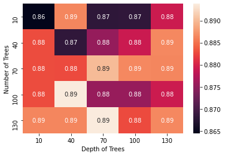

```python
np.random.seed(68)
rf_best_param = rf_choose_best_param(X21_train, y21_train, folds_indexes_4, num_trees, depth_trees, sample_weights=None)
print('rf_best_param:', rf_best_param)
```

### 2.1.2

Now we have found the optimal values for our hyper-parameters we want to see how well our Random Forest performs on a test dataset. Let us read in our test dataset and prepare it.

```python
# load diabetes_test data into a Pandas DataFrame using the read_csv function
df_test = pd.read_csv('diabetes_test.csv',sep=',',decimal=',')

# set patient number as index of DataFrame
df2_test = df_test.set_index(df_test['patient_number']).drop(df_test.columns[0], axis=1)

# convert categorical diabetes column to binary
diag_map = {'Diabetes': 1.0, 'No diabetes': -1.0}
df2_test['diabetes'] = df2_test['diabetes'].map(diag_map)

# obtain predictor and target variables using .iloc and .loc
X21_test = df2_test.iloc[:,:-1]
y21_test = df2_test.loc[:, 'diabetes']
```

Now we will retrain the optimal random forest on $\textit{diabetes_samples.csv}$ and compare the performance of the model on $\textit{diabetes_samples.csv}$ and $\textit{diabetes_test.csv}$. To do so we will compare the precision and F-score of our random forest mode.

Precision is a measure of the proportion of true positives out of total predicted positives. It is a measure of the accuracy of postiive predictions and a high precision score means there are few false positives among total positive predictions. It is given by:

$$ \text{Precision} = \frac{\text{True Positives}}{\text{True Positives + False Positives}}.$$

The F-score is a measure of the model's accuracy considering both the precison and recall where the recall is the sensitivty or true positive rate measuring the proportion of positive cases correctly identified. in the case of unbalanced data the F-score is a better measure than accuracy. That is it has identified a high percentage of positive samples while keeping the number of false positives low. The F-score is given by:

$$ \text{F-score} = \frac{\text{True Positive}}{\text{True Positive} + \frac{1}{2}(\text{False Positive + False Negative)}}.$$

```python
def rf_precision(rf, X_test, y_test):
    """
    Calculates the precision of a random forest classifier on a test dataset

    Args:
        rf: a random forest model
        X_test: array of test input
        y_test: vector of test output

    Returns:
        precision: precision of random forest
    """
    # create prediction using random forest on test data
    y_pred = predict_rf(rf, X_test.to_numpy())

    # create copies of test and predictions to change -1 values to 0 so np.sum can be used
    y_test_copy = y_test.copy()
    y_pred_copy = y_pred.copy()

    y_test_copy[y_test_copy == -1] = 0
    y_pred_copy[y_pred_copy == -1] = 0

    # convert to int so & can be used
    y_test = y_test.astype(int)
    y_pred = y_pred.astype(int)

    # calculate number true positives and false positives
    tp = np.sum(y_test & y_pred)
    fp = np.sum((~y_test) & y_pred)

    return tp/(tp+fp)
```

Next we will define a function `rf_fscore` to compute the F-score for our Random Forest Classifier.

```python
def rf_fscore(rf, X_test, y_test):
    """
    Calculates the F-score of a random forest classifier on a test dataset

    Args:
        rf: a random forest model
        X_test: array of test input
        y_test: vector of test output

    Returns:
        precision: precision of random forest
    """
    # create prediction using random forest on test data
    y_pred = predict_rf(rf, X_test.to_numpy())

    # create copies of test and predictions to change -1 values to 0 so np.sum can be used
    y_test_copy = y_test.copy()
    y_pred_copy = y_pred.copy()

    y_test_copy[y_test_copy == -1] = 0
    y_pred_copy[y_pred_copy == -1] = 0

    # convert to int so & can be used
    y_test = y_test.astype(int)
    y_pred = y_pred.astype(int)

    # calculate number of true positives, false positives and false negatives
    tp = np.sum(y_test & y_pred)
    fp = np.sum((~y_test) & y_pred)
    fn = np.sum(y_test & (~y_pred))

    return tp/(tp + 0.5*(fp + fn))
```

```python
np.random.seed(68)
rf = train_rf(rf_best_param[0], n_features, X21_train, y21_train,  columns_dict, rf_best_param[1], sample_weights=None)
print(f'Accuracy on training set:', rf_score(rf, X21_train.to_numpy(), y21_train.to_numpy()))
print(f'Accuracy on test set:', rf_score(rf, X21_test.to_numpy(), y21_test.to_numpy()))
```

```
Accuracy on training set: 1.0
Accuracy on test set: 0.9316239316239316
```

We can see that our Random Forest Classifier has a better accuracy on the training data than the test data as expected. However let us now compute some more measures to evaluate the performance, in particular the precision and F-score. First we will create an `rf_precision` function to calculate the precision.

```python
print(f'Precision on training set:', rf_precision(rf, X21_train, y21_train))
print(f'Precision on test set:', rf_precision(rf, X21_test, y21_test))
```

```
Precision on training set: 1.0
Precision on test set: 0.8709677419354839
```

```python
print(f'F-score on training set:', rf_fscore(rf, X21_train, y21_train))
print(f'F-score on test set:', rf_fscore(rf, X21_test, y21_test))
```

```
F-score on training set: 1.0
F-score on test set: 0.9101123595505618
```

We can see that on the training data our unbalanced random forest has scores of 1 for all measures which we would expect since we built our random forest on this training data but measures on the test set decrease as expected. However, the relatively high accuracy and F-score on the test data can be misleading as the values can be dominated by majority classes and the model performing badly on minority classes. the lower precision score means that the model is correctly identifying most of the positive cases but also misclassifying the negative instances as positives. In the context of our data it is ideal to rectify and improve our model as much as possible since falsely predicting diabetes is dangerous. To further improve our model we should look at more metrics and also explore whether our data is unbalanced or not.

### 2.1.3

We have computed different measures to evaluate our Random Forest classifier, but let us take a closer look at our dataset. In particular let us compute the frequencies of diagnosis outcomes.

```python
diab_not, diab = y21_train.value_counts()
print(f'Number of non-diabetics:', diab_not)
print(f'Number of diabetics:', diab)
```

```
Number of non-diabetics: 229
Number of diabetics: 44
```

We see that our dataset $\textit{diabetes_samples.csv}$ is unbalanced, therefore we will introduce appropiate weights for each data point to balance diagnosis outcomes. We will perform 4-fold cross-validation on the training set with sample weights to find a new pair of optimal hyper-parameters by changing the argument of `rf_choose_best_param`.

```
CV_ACC@num_tree=10, depth_trees=10: 0.890079
CV_ACC@num_tree=10, depth_trees=40: 0.879156
CV_ACC@num_tree=10, depth_trees=70: 0.879049
CV_ACC@num_tree=10, depth_trees=100: 0.879156
CV_ACC@num_tree=10, depth_trees=130: 0.864503
CV_ACC@num_tree=40, depth_trees=10: 0.868180
CV_ACC@num_tree=40, depth_trees=40: 0.897432
CV_ACC@num_tree=40, depth_trees=70: 0.890132
CV_ACC@num_tree=40, depth_trees=100: 0.879209
CV_ACC@num_tree=40, depth_trees=130: 0.875533
CV_ACC@num_tree=70, depth_trees=10: 0.882779
CV_ACC@num_tree=70, depth_trees=40: 0.875426
CV_ACC@num_tree=70, depth_trees=70: 0.890132
CV_ACC@num_tree=70, depth_trees=100: 0.875533
CV_ACC@num_tree=70, depth_trees=130: 0.875480
CV_ACC@num_tree=100, depth_trees=10: 0.879103
CV_ACC@num_tree=100, depth_trees=40: 0.871803
CV_ACC@num_tree=100, depth_trees=70: 0.875533
CV_ACC@num_tree=100, depth_trees=100: 0.868073
CV_ACC@num_tree=100, depth_trees=130: 0.875480
CV_ACC@num_tree=130, depth_trees=10: 0.879103
CV_ACC@num_tree=130, depth_trees=40: 0.875480
CV_ACC@num_tree=130, depth_trees=70: 0.882779
CV_ACC@num_tree=130, depth_trees=100: 0.886456
CV_ACC@num_tree=130, depth_trees=130: 0.871856
rf_weighted_best_param: (40, 40)
```

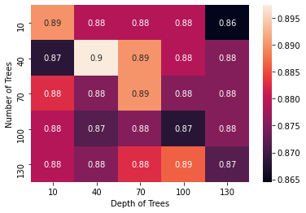

```python
np.random.seed(68)
rf_weighted_best_param = rf_choose_best_param(X21_train, y21_train, folds_indexes_4, num_trees, depth_trees, sample_weights=sample_weight)
print('rf_weighted_best_param:', rf_weighted_best_param)
```

Now we have shown that our dataset is unbalanced and performed cross-validation with the new sample weights let us now train our weighted random forest with weighted bootstrap.

```python
y21_train_bootstrap = sample_weight(y21_train)
```

```python
rf_weighted = train_rf(rf_weighted_best_param[0], n_features, X21_train, y21_train,  columns_dict, rf_weighted_best_param[1], bootstrap=y21_train_bootstrap)
```

Now we have found a new pair of optimal hyper-parameters for the case when we don't have uniform sample weights let us compare the two different random forests. To do so we will plot the ROC curve and Precision-Recall curve to discuss the performances.

Let us first make predictions using our unweighted `rf` and weighted `rf_weighted` on the train and test data.

```python
y21_train_pred = predict_rf(rf, X21_train.to_numpy())
y21_test_pred = predict_rf(rf, X21_test.to_numpy())
y21_train_pred_weighted = predict_rf(rf_weighted, X21_train.to_numpy())
y21_test_pred_weighted = predict_rf(rf_weighted, X21_test.to_numpy())
```

Next we will define a function `predict_rf_prob` which computes the probability of each data point being classified as diabetic or not which we will use in our ROC and Precision-Recall curves.

```python
def predict_rf_prob(rf, X):
    """
  Predict probability of each data point in X.
  Args:
      rf: A trained random forest through train_rf function.
      X: (pd.Dataframe) testing sample features, of shape (N, D).
  Returns:
      (np.array): predicted testing sample labels, of shape (N,).
  """

    def aggregate(decisions):
        count = defaultdict(int)
        for decision in decisions:
            count[decision] += 1
        return count[1]/len(decisions)

    if len(X.shape) == 1:
        return aggregate([classify(tree, X) for tree in rf])
    else:
        return np.array([aggregate([classify(tree, x) for tree in rf]) for x in X])
```

Now we have created `predict_rf_prob` let us compute the probability of each data point belonging to diabetic or non diabetic on the train and test data using both the unweighted and weighted random forest.

```python
y21_train_prob = predict_rf_prob(rf, X21_train.to_numpy())
y21_test_prob = predict_rf_prob(rf, X21_test.to_numpy())
y21_train_prob_weighted = predict_rf_prob(rf_weighted, X21_train.to_numpy())
y21_test_prob_weighted = predict_rf_prob(rf_weighted, X21_test.to_numpy())
```

Now we have the probabilities and our predictions let us create a function `roc_pr_curve` which creates an ROC and Precision-Recall curve for us. The ROC curve demonstrates the performance of a classification model at various different classifcation thresholds and typically more useful for balanced data. On the other hand, Precision-Recall curves are typically used for evaluation on unbalanced data and is used to evaluate a model's ability at correctly identifying true positives while minimising false positives. Recall is defined as:

$$\text{Recall} = \frac{\text{True Positive}}{\text{True Positive + False Negative}}.$$

```python
def roc_pr_curve(y_true, y_prob):
    """
    Produce ROC and Precision-Recall curves

    Args:
        y_true: ground truth labels with size (n, )
        y_prob: probabilities produced by random forest model with size (n, )

    Returns:
        aucROC: area under ROC curve.
        aucPR: area under Precision-Recall curve
        tpr_l: a list of true positive rate (TPR) values for each scanned threshold.
        fpr_l: a list of false positive rate (FPR) values for each scanned threshold.
        thresholds: the scanned thresholds sorted descendingly.
        precision_l: a list of precision values for each scanned threshold
    """
    # list of distinct values in y_prob, sorted descendingly.
    thresholds = reversed(sorted(set(y_prob)))
    tpr_l, fpr_l, precision_l = [], [], []

    # create copy of y_true changing values to boolean
    y_true_copy = y_true.copy()
    y_true_copy = np.where(y_true_copy > 0, True, False)

    for threshold in thresholds:
        # apply thresholding
        y_thresholded = (y_prob >= threshold)

        # true positives
        tp = np.sum(y_true_copy & y_thresholded)
        # true negatives
        tn = np.sum((~y_true_copy) & (~y_thresholded))
        # false positives
        fp = np.sum((~y_true_copy) & y_thresholded)
        # false negatives
        fn = np.sum(y_true_copy & (~y_thresholded))

        # calculate true and false positive rate
        tpr = tp / (tp + fn)
        fpr = fp / (tn + fp)
        tpr_l.append(tpr)
        fpr_l.append(fpr)

        # calculate precision
        precision = tp/(tp+fp)
        precision_l.append(precision)

    # compute ROC AUC using Trapezoidal rule
    aucROC = np.trapz(tpr_l, fpr_l)

    # compute PR AUC using Trapezoidal rule
    aucPR = np.trapz(precision_l, tpr_l)

    return aucROC, aucPR, tpr_l, fpr_l, thresholds, precision_l
```

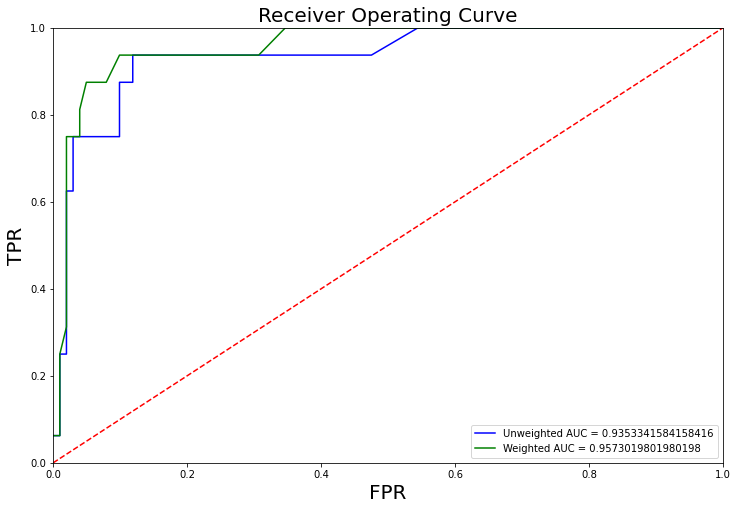

```python
aucROCu, aucPRu, tpru, fpru, thu, preciu = roc_pr_curve(y21_test, y21_test_prob)
aucROCw, aucPRw, tprw, fprw, thw, preciw = roc_pr_curve(y21_test, y21_test_prob_weighted)

plt.figure(figsize=(12,8))
plt.title(f"Receiver Operating Curve", size=20)
plt.plot(fpru, tpru, 'b', label = f'Unweighted AUC = {aucROCu:}')
plt.plot(fprw, tprw, 'b', label = f'Weighted AUC = {aucROCw:}', color =  'g')
plt.legend(loc = 'lower right')
plt.plot([0, 1], [0, 1],'r--')
plt.xlim([0, 1])
plt.ylim([0, 1])
plt.ylabel('TPR', size=20)
plt.xlabel('FPR', size=20)
plt.show()
```

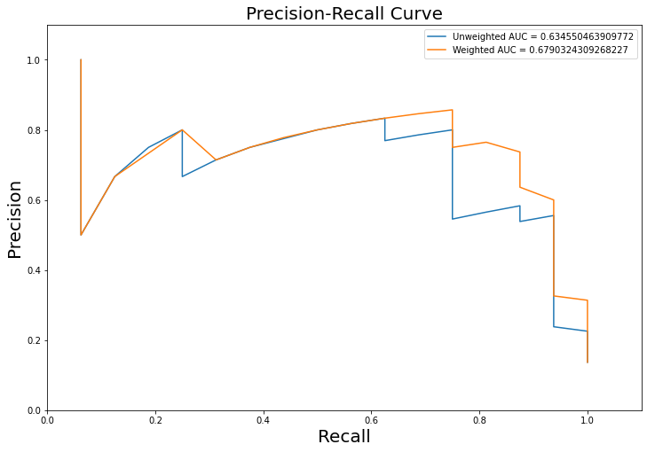

```python
plt.figure(figsize=(12,8))
plt.title(f"Precision-Recall Curve", size=20)
plt.plot(tpru, preciu, label = f'Unweighted AUC = {aucPRu:}')
plt.plot(tprw, preciw, label = f'Weighted AUC = {aucPRw:}')
plt.legend()
plt.xlim([0, 1.1])
plt.ylim([0, 1.1])
plt.ylabel('Precision', size=20)
plt.xlabel('Recall', size=20)
plt.show()
```

We see that the AUC on the weighted bootstrap is higher than that of the standard bootstrap on both graphs. This higher AUC on both graphs mean that the weighted bootstrap is better at distinguishing between positive and negative samples and that it is better at identifying positive samples. This suggests that orignally our data was unbalanced and after introducing weighted bootstrap our model performs better; relating this to the context of diabetes diagnosis this is essenital since incorrect diagnoses can lead to deaths or mistreatments.

## 2.2 Support Vector Machine (SVM) (30 marks)

### 2.2.1

We have seen how to implement a Random Forest Classifier previously but let us now shift our focus to Support Vector Machines.

Support vector machine models try to find the optimal hyperplane that best separates the different classes in the feature space, we will train a soft-margin linear SVM classifier by minimising the loss function,

$$ L (\boldsymbol w) = \frac{1}{2} \| \boldsymbol w \|^2 + \lambda \sum_{i=1}^n \max \left\{ 0, 1- y^{(i)} (x^{(i)} \cdot \boldsymbol w + b) \right\},$$

on the $\textit{diabetes_samples.csv}$ dataset. To optimise the cost function we will use stochastic gradient descent and obtain the weights. We will employ 4-fold cross-validation to optimise the hardness hyper-parameter $\lambda$ using accuracy as our performance measure. Before we start let us prepare our data for this section.

```python
# load diabetes_sample data into a Pandas DataFrame using the read.csv function
d = pd.read_csv('diabetes_samples.csv',sep=',',decimal=',')
# set patient number as index of DataFrame
dd = d.set_index(d['patient_number']).drop(d.columns[0], axis=1)

# convert categorical diabetes column to binary
diag_map = {'Diabetes': 1.0, 'No diabetes': -1.0}
dd['diabetes'] = dd['diabetes'].map(diag_map)

# obtain predictor and target variables then standardise predictor variable
y22_train = dd.loc[:,'diabetes'].to_numpy()
diab_mean = np.mean(dd.iloc[:,:-1], axis=0)
diab_std = np.std(dd.iloc[:,:-1], axis=0)
X22_train = ((dd.iloc[:,:-1] - diab_mean)/diab_std).to_numpy()

# we will insert 1 to every row of X for the intercept b
X22_train_intercept = np.hstack((X22_train, np.ones((len(X22_train),1)) ))
```

Now we have prepared our data let us implement our cost function below.

```python
def svm_compute_cost(w, X, y, regul_strength):
    """
    Compute cost function

    Args:
        w: array of weights which are the normals of the hyperplane
        X: array of data
        y: array of labels
        regul_strength: float, hyper-parameter (lambda)

    Returns:
        value of cost function
    """
    n = X.shape[0]
    distances = 1 - y * (X @ w) # distance between each point and the hyperplane
    distances[distances < 0] = 0  # equivalent to max(0, distance)
    hinge = regul_strength * distances.mean()

    # calculate cost
    return 0.5 * np.dot(w, w) + hinge -0.5*w[-1]**2
```

Now we have implemented our cost function let's create a function which calculates the gradient with respect to $\boldsymbol w$ to use for stochastic gradient descent below. First, we must calculate the derivative:

$$ \frac{\partial L}{\partial \boldsymbol w} = \begin{cases} w & 1- y^{(i)} (x^{(i)} \cdot \boldsymbol w + b) \leq 0 \\ w - (\lambda \cdot y^{(i)} \cdot x^{(i)}) & 1- y^{(i)} (x^{(i)} \cdot \boldsymbol w + b) > 0 \\ \end{cases}.$$

Now that we have computed the gradients we can implement in `svm_calculate_cost_gradient` below.

```python
def svm_calculate_cost_gradient(w, X_batch, y_batch, regul_strength):
    """
    Compute average gradient of cost function with respect to w

    Args:
        w: vector of weights
        X_batch: array where each row is data X
        y_batch: array labels of X_batch
        regul_strength: float, hyper-parameter (lambda)

    Returns:
        Average gradient with respect to w
    """
    # if only one example is passed convert to numpy array
    if type(y_batch) == np.float64:
        y_batch = np.asarray([y_batch])
        X_batch = np.asarray([X_batch])  # gives multidimensional array

    distance = 1 - (y_batch * (X_batch @ w))
    dw = np.zeros(len(w)) # arary to store derivatives

    we = w.copy() # So as not to overwrite w
    we[-1] = 0 # So as not to have b in its derivative when adding the weights in di

    # find gradient of cost function with each batch
    for ind, d in enumerate(distance):
        if max(0, d)==0:
            di = we # derivative of first term
        else:
            di = we - (regul_strength * y_batch[ind] * X_batch[ind]) # derivative of hinge loss
        dw += di

    return dw/len(y_batch)  # average
```

We can now implement stochastic gradient descent by calling `svm_calculate_cost_gradient` at each iteration. We will implement the algorithm with a default learning rate $\alpha$ and include a stop criterion that ends the learning once the cost function hasn't not changed by a chosen percentage. In stochastic gradient descent we update the weights following,

$$ \boldsymbol w = \boldsymbol w - \alpha \frac{\partial L}{\partial \boldsymbol w},$$

with the gradient having been calculated in `svm_calculate_cost_gradient`.

```python
def sgd(X, y, regul_strength, max_iterations=5000, stop_criterion=0.0001, learning_rate=1e-4, print_outcome=False):
    """
    Perform stochastic gradient descent on cost function

    Args:
        X: array of data
        y: vector of labels of X
        regul_strength: float, hyper-parameter (lambda)
        max_iterations: int, maximum number of iterations
        stop_criterion: float, stop algorithm once previous two iterations' cost
        has a percentage difference of stop_criterion
        learning_rate: float, determines speed of descent
        print_outcome: boolean, True means print cost at ith iteration

    Returns:
        weights: array of weights (normal to hyperplane)
    """
    # initialise zero weights
    weights = np.zeros(X.shape[1])
    nth = 0
    # initialise starting cost as infinity
    prev_cost = np.inf

    # stochastic gradient descent
    indices = np.arange(len(y))

    for iteration in range(1, max_iterations):
        # shuffle to prevent repeating update cycles
        np.random.shuffle(indices)
        X, y = X[indices], y[indices]

        # perform gradient descent by rows
        for xi, yi in zip(X, y):
            descent = svm_calculate_cost_gradient(weights, xi, yi, regul_strength)
            weights = weights - (learning_rate * descent)

        # convergence check on 2^n'th iteration
        if iteration==2**nth or iteration==max_iterations-1:
            # compute cost
            cost = svm_compute_cost(weights, X, y, regul_strength)
            if print_outcome:
                print("Iteration is: {}, Cost is: {}".format(iteration, cost))
            # stop criterion
            if abs(prev_cost - cost) < stop_criterion * prev_cost:
                return weights

            prev_cost = cost
            nth += 1

    return weights
```

We have implemented stochastic gradient descent, naturally we wish to evaluate the performance which we will do by using accuracy as our measure.

```python
def svm_score(X_train, y_train, X_test, y_test, k):
    """
    Compute accuracy of model

    Args:
        X_train: array of training input
        y_train: array of training output
        X_test: array of test input
        y_test: array of test output
        k: hyper-parameter (lambda)

    Returns:
        Accuracy of model
    """
    # obtain weights by stochastic gradient descent
    w = sgd(X_train, y_train, k)
    # form predictions on test set
    y_preds = np.sign(X_test @ w)

    return np.mean(y_preds == y_test)
```

Now that we have implemented stochastic gradient descent to determine the weights we can perform 4-fold cross-validation. First we will create our folds which will be a permutation of the natural index unlike the previous sections, this is because we are not permuting our training data in this section.

```python
def svm_cross_val_split(N, num_folds):
    """
    Return shuffled indices of folds

    Args:
        N: int, sample size
        num_folds: int, number of folds

    Returns:
        folds: list of arrays of shuffled indices
    """
    fold_size = N // num_folds
    index_perm = np.random.permutation(np.arange(N)) # obtain random permutation of indices
    folds = []
    for k in range(num_folds):
        folds.append(index_perm[k*fold_size:(k+1)*fold_size])
    return folds

np.random.seed(12358)
# obtain 4 folds
svm_folds = svm_cross_val_split(X22_train_intercept.shape[0], 4)
```

Let us now implement our 4-fold cross-validation below.

```python
def svm_cross_validation_score(X_train, y_train, folds, k):
    """
    Perform T-fold cross-validation on a value k

    Args:
        X_train: array of training input
        y_train: vector of training output
        folds: array where each row contains indices of folds
        k: hyper-parameter for tuning (lambda)

    Returns:
        Average accuracy over folds
    """
    # empty list to store scores
    scores = []
    for i in range(len(folds)):
        # get indices of validation set
        val_indexes = folds[i]
        # get indices of training set by subtracting val_indexes indices
        train_indexes = list(set(range(y_train.shape[0])) - set(val_indexes))

        # get training set
        X_train_i = X_train[train_indexes, :]
        y_train_i = y_train[train_indexes]

        # get validation set
        X_val_i = X_train[val_indexes, :]
        y_val_i = y_train[val_indexes]

        # calculate score (accuracy) of set
        score_i = svm_score(X_train_i, y_train_i, X_val_i, y_val_i, k=k)
        scores.append(score_i)

    # Return the average score
    return sum(scores) / len(scores)
```

Now let us implement a function which performs cross-validation over a range of values and selects the optimal hyper-parameter.

```python
def svm_choose_best_k(X_train, y_train, folds, k_range):
    """
    Provided a list of hyper-parameters (k_range), selects the parameter, k, providing the highest accuracy

    Args:
        X_train: array of training input
        y_train: vector of training output
        folds: array where each row contains indices of folds
        k: hyper-parameter for tuning (lambda)

    Returns:
        plot of k_range against k_scores
        k_range[best_k_index]: best k which provides highest accuracy
    """
    # array to store scores
    k_scores = np.zeros((len(k_range),))
    for i, k in enumerate(k_range):
        # calculate score for each k and fold
        k_scores[i] = svm_cross_validation_score(X_train, y_train, folds, k)
        # print ith parameter and corresponding score
        print(f'CV_ACC@k={k}: {k_scores[i]}')

    # choose best k by finding index that gives largest accuracy
    best_k_index = np.argmax(k_scores)

    # plot range of k against accuracy
    plt.figure(figsize=(12,8))
    plt.plot(k_range, k_scores)
    plt.xlabel('Lambda Range')
    plt.ylabel('Average Accuracy')
    plt.title('Hardness Parameter Lambda Against Average Accuracy')
    plt.xscale('log')
    plt.show()

    return k_range[best_k_index]
```

Now we have implemented cross-validation for SVM let us perform 4-fold cross-validation across our hardness hyper-parameter.

```
CV_ACC@k=0.01: 0.838235294117647
CV_ACC@k=0.03162277660168379: 0.838235294117647
CV_ACC@k=0.1: 0.838235294117647
CV_ACC@k=0.31622776601683794: 0.838235294117647
CV_ACC@k=1.0: 0.8419117647058822
CV_ACC@k=3.1622776601683795: 0.886029411764706
CV_ACC@k=10.0: 0.9044117647058824
CV_ACC@k=31.622776601683793: 0.9044117647058824
CV_ACC@k=100.0: 0.9117647058823529
CV_ACC@k=316.22776601683796: 0.9154411764705882
CV_ACC@k=1000.0: 0.886029411764706
CV_ACC@k=3162.2776601683795: 0.8823529411764707
CV_ACC@k=10000.0: 0.9154411764705882
CV_ACC@k=31622.776601683792: 0.875
CV_ACC@k=100000.0: 0.8602941176470588
CV_ACC@k=316227.7660168379: 0.8713235294117647
```

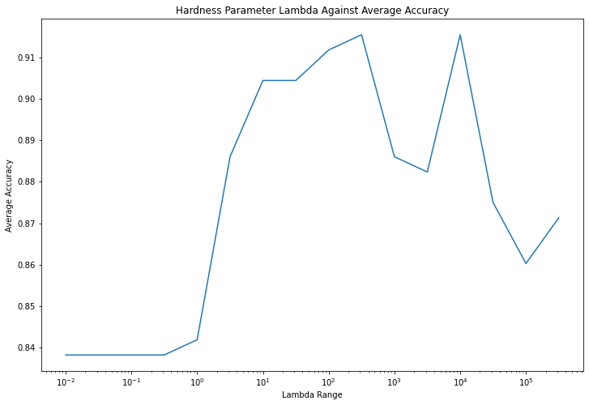

```
SVM optimal lambda: 316.22776601683796
```

```python
# set seed for reproducibility
np.random.seed(7235)
# range of lambda to scan over
svm_range = [10**i for i in np.arange(-2,6,0.5, dtype=float)]
# perform cross-validation to find optimal lambda
svm_best_k = svm_choose_best_k(X22_train_intercept, y22_train, svm_folds, svm_range)
print('SVM optimal lambda:', svm_best_k)
```

### 2.2.2

Now, for each of the hardness hyper-parameters examined in $\textbf{2.2.1}$ we will calculate the cosine of the angle between each pair of hyperplanes reporting the results as a square heatmap as a function of the hardness hyper-parameter $\lambda$ for each hyperplane.

Consider two hyperplanes, $i$ and $j$ with respective normal vectors $w_i, w_j$. We define the cosine of the angle between the two hyperplanes as:

$$\cos(\phi) = \frac{w_i \cdot w_j}{||w_i|| ||w_j||}.$$

We write a function below to calculate the cosine of the angle between the hyperplanes.

```python
def cosine_angle(X, y, lambds):
    """
    Calculate cosine angle between hyperplanes formed by weights

    Args:
        X: array of data
        y: array of labels of X
        lambds: range of lambda to calculate weights

    Returns:
        mat: matrix of cosine angles
    """
    # empty dictionary to populate with weights from corresponding lambda as key
    weights = {}
    for i in range(len(lambds)):
        weights[lambds[i]] = sgd(X, y, lambds[i])

    # calculate norm of each weight vector and storing in dictionary
    norms = {k: np.linalg.norm(v) for k, v in weights.items()}

    # obtain indices of lower triangular matrix
    row_idx, col_idx = np.tril_indices(len(lambds))

    # initialise matrix to append values to
    mat = np.zeros((len(lambds), len(lambds)))

    # for loop calculating cosine angle between hyperplane over indices of lower triangular matrix (O(n^2/2))
    for i, j in zip(row_idx, col_idx):
        if i == j:
            mat[i,j] = 1
        else:
            mat[i,j] = np.dot(weights[lambds[i]], weights[lambds[j]])/(norms[lambds[i]]*norms[lambds[j]])
            mat[j,i] = np.dot(weights[lambds[i]], weights[lambds[j]])/(norms[lambds[i]]*norms[lambds[j]])

    return mat
```

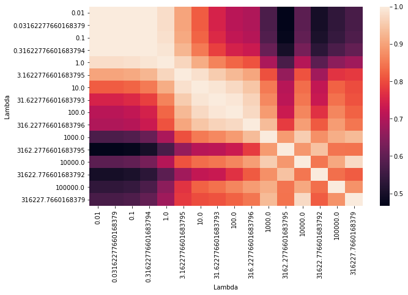

```python
cos_ang_mat = cosine_angle(X22_train_intercept, y22_train, svm_range)
plt.figure(figsize=(10,6))
sns.heatmap(cos_ang_mat, xticklabels = svm_range, yticklabels = svm_range)
plt.xlabel('Lambda')
plt.ylabel('Lambda')
plt.show()
```

The SVM try to find hyperplanes that have a large margin of separation between the classes. The cosine angle between hyperplanes is a measure of similarity or dissimilarity if the cosine angle is close to 1 the hyperplanes are similar to each other and therfore a high degree of overlap between the feature spaces and vice versa. We see that in general $\lambda$ values close to each other tend to have a cosine angle closer to 1. Additionally, cosine angles close to 1 indicate that the hyperplanes are similar to each other and therefore the classes are harder to separate.

### 2.2.3

Now that we have optimised the hardness hyper-paramter $\lambda$ we will re-train our linear SVM on this optimal value on the full dataset $\textit{diabetes_samples.csv}$ and evaulate the performance on the test data $\textit{diabetes_test.csv}$ using accuracy, precision and F-score. Before we start let us import and prepare the test dataset.

```python
# load diabetes_test data into a Pandas DataFrame using the read_csv function
g = pd.read_csv('diabetes_test.csv', sep=',', decimal=',')
# drop first column and make patient_number index of DataFrame
gg = g.set_index(g['patient_number']).drop(g.columns[0], axis=1)
# create dictionary to change diabetes from categorical to binary
diag_map = {'Diabetes': 1.0, 'No diabetes': -1.0}
gg['diabetes'] = gg['diabetes'].map(diag_map)

# create target and predictor variables using .loc and .iloc converting to numpy
# standardise predictor variable then add one to every row for intercept
y22_test = gg.loc[:,'diabetes'].to_numpy()
X22_test = ((gg.iloc[:,:-1] - diab_mean)/diab_std).to_numpy()
X22_test_intercept = np.hstack((X22_test, np.ones((len(X22_test),1)) ))
```

Now our data is ready let us create functions to evaluate the performance of the linear SVM on the test data. The first function we will define is the accuracy, `svm_accuracy`.

```python
def svm_accuracy(X_train, y_train, X_test, y_test, lambd):
    """
    Computes accuracy of linear SVM

    Args:
        X_train: array of training input
        y_train: vector of training output
        X_test: array of test input
        y_test: vector of test input
        lambd: float, hyper-parameter

    Returns:
        Accuracy of linear SVM
    """
    # calculate weights from training data and lambda
    w = sgd(X_train, y_train, lambd)
    # form prediction from calculated weight on test
    y_pred = np.sign(X_test @ w)

    return np.mean(y_pred == y_test) # compute accuracy
```

Next we create `svm_precision` to compute the precision of the linear SVM.

```python
def svm_precision(X_train, y_train, X_test, y_test, lambd):
    """
    Computes precision of linear SVM

    Args:
        X_train: array of training input
        y_train: vector of training output
        X_test: array of test input
        y_test: vector of test input
        lambd: float, hyper-parameter

    Returns:
        Precision of linear SVM
    """
    # calculate weights from training data and lambda
    w = sgd(X_train, y_train, lambd)
    # form prediction from calculated weight on test
    y_pred = np.sign(X_test @ w)

    # make copies to prevent over-writing
    y_test_copy = y_test.copy()
    y_pred_copy = y_pred.copy()

    # change values of -1 to 0 so can use np.sum
    y_test_copy[y_test_copy == -1] = 0
    y_pred_copy[y_pred_copy == -1] = 0

    y_test_copy = y_test_copy.astype(int)
    y_pred_copy = y_pred_copy.astype(int)

    # calculate true positives and false positives
    tp = np.sum(y_test_copy & y_pred_copy)
    fp = np.sum((~y_test_copy) & y_pred_copy)

    return tp/(tp+fp)
```

The last measure we will use wil bee the F-score, `svm_fscore`.

```python
def svm_fscore(X_train, y_train, X_test, y_test, lambd):
    """
    Computes F-score of linear SVM

    Args:
        X_train: array of training input
        y_train: vector of training output
        X_test: array of test input
        y_test: vector of test input
        lambd: float, hyper-parameter

    Returns:
        F-score of linear SVM
    """
    # calculate weights from training data and lambda
    w = sgd(X_train, y_train, lambd)
    # form prediction from calculated weight on test
    y_pred = np.sign(X_test @ w)

    # make copies to prevent over-writing
    y_test_copy = y_test.copy()
    y_pred_copy = y_pred.copy()

    # change values of -1 to 0 so can use np.sum
    y_test_copy[y_test_copy == -1] = 0
    y_pred_copy[y_pred_copy == -1] = 0

    y_test_copy = y_test_copy.astype(int)
    y_pred_copy = y_pred_copy.astype(int)

    # calculate true positives and false positives
    tp = np.sum(y_test_copy & y_pred_copy)
    fp = np.sum((~y_test_copy) & y_pred_copy)
    fn = np.sum(y_test_copy & (~y_pred_copy))

    return tp/(tp + 0.5*(fp + fn))
```

Now we have created our functions to evaluate the performances let us see the results.

```python
np.random.seed(17)
print(f'Linear SVM Test Accuracy:', svm_accuracy(X22_train_intercept, y22_train, X22_test_intercept, y22_test, svm_best_k))
print(f'Linear SVM Test Precision:', svm_precision(X22_train_intercept, y22_train, X22_test_intercept, y22_test, svm_best_k))
print(f'Linear SVM Test F-score:', svm_fscore(X22_train_intercept, y22_train, X22_test_intercept, y22_test, svm_best_k))
```

```
Linear SVM Test Accuracy: 0.9316239316239316
Linear SVM Test Precision: 0.8333333333333334
Linear SVM Test F-score: 0.7333333333333333
```

We see that the accuracy of our linear SVM model is relatively high whcih indicates the model is performing well in predicting the classes; meaning that is able to separate the classes relatively well with a linear boundary. The precision of our model indicates that the model is able to identify most of the relevant data points as positive while keeping the number of false positives low. However, the F-score refelcts a model that is correctly classifying a reasonable proportion of both positive and negative instances but with misclassifications. These results suggest we should look to modify our SVM possibly changing our kernel.

### 2.2.4

We will now implement a soft-margin kernelised SVM classifier by minimising the loss function:

$$L(\mathbf{u},b) = \frac{1}{2}\mathbf{u}^{\rm{T}}\mathbf{K} \mathbf{u} + \lambda \sum_{i=1}^N \max \Big\{0, 1-y^{(i)}(\mathbf{K}^{(i)}\mathbf{u} + b)\Big\}$$

with respect to $\textbf{u}$ and $b$. We will use the sigmoid kernel defined as:

$$\left[\textbf{K}\right]_{ij} \equiv k(\textbf{x}^{(i)}, \textbf{x}^{(j)}) = \text{tanh} \left(\sigma \left(\textbf{x}^{(i)} \cdot \textbf{x}^{(j)} \right) + 1 \right).$$

We now explore kernerlised SVM classifier to explore the idea of nonlinear classifications where a linear boundary is not sufficient. It works by transforming the input features into higher dimensional features using a kernel function which allows the algorithm to find a nonlinear decision boundary in the transformed space that corresponds to a linear decision boundary in the original space. This allows the model to handle more complex data compared to linear SVM.

We will set the hardness parameter to $\lambda =10$ and train the soft-margin kernelised SVM classifer on $\textit{diabetes_samnples.csv}$ for $\sigma \in \{0.01, 0.1, 1, 2\}$

To implement a soft-margin kernelised SVM classifier we must implement our sigmoid kernel below.

```python
def kernel_matrix(X1, X2, sigma):
    """
    Computes sigmoid kernel

    Args:
        X1: array with each row representing data
        X2: array with each row representing data
        sigma: float, parameter of sigmoid kernel

    Returns:
        sigmoid kernel: array, sigmoid kernel
    """
    kernel = np.tanh(sigma * X1 @ X2.T + 1)
    return kernel
```

Now that we have implemented our sigmoid kernel let us define our new cost below.

```python
def compute_cost_kernel(u, K, y, regul_strength, intercept):
    """
    Compute cost with sigmoid kernel

    Args:
        u: vector, weights
        K: array, kernel matrix
        y: array, labels of data
        regul_strength: float, hyper-parameter (lambda)
        intercept: value of b in cost function

    Returns:
        cost: value of cost function
    """

    distances = 1 - (y)*(K@u + intercept)
    distances[distances < 0] = 0  # equivalent to max(0, distance)
    hinge = regul_strength * distances.mean()

    # calculate cost
    return 0.5 * np.dot(u,K@u) + hinge
```

Now we have defined a function for the new cost function. To optimise our cost function we will use stochastic gradiet descent which is similar to that of gradient descent but is faster due to calculating the gradeint of a random batch at every iteration. Before we can use stochastic gradient descent we need to define a new function to calculate the gradients of our cost function. We must modify our function since we do not assume $b=0$ in this part. Computing the derivative with respect to $\mathbf{u}$ and $b$ of our kernel cost function we get,

$$ \frac{\partial L}{\partial \mathbf{u}} = \begin{cases} \mathbf{K} \mathbf{u} & 1- y^{(i)} (\mathbf{K}^{(i)}\mathbf{u} + b) \leq 0 \\ \mathbf{K} \mathbf{u} - \lambda \sum_{i=1}^{N} y^{(i)} \mathbf{K}^{(i)} & 1- y^{(i)} (\mathbf{K}^{(i)}\mathbf{u} + b) > 0, \\ \end{cases} $$

and

$$ \frac{\partial L}{\partial b} = \begin{cases} 0 & 1- y^{(i)} (\mathbf{K}^{(i)}\mathbf{u} + b) \leq 0 \\ - \lambda \sum_{i=1}^{N} y^{(i)} & 1- y^{(i)} (\mathbf{K}^{(i)}\mathbf{u} + b) > 0. \\ \end{cases} $$

Now we can implement the gradients below.

```python
def calculate_cost_gradient_kernel(u, K_batch, y_batch, regul_strength, intercept):

    # if only one example is passed
    if type(y_batch) == np.float64 or type(y_batch) == np.int32:
        y_batch = np.asarray([y_batch])
        K_batch = np.asarray([K_batch])  # gives multidimensional array

    distance = 1 - (y_batch * (K_batch @ u + intercept))
    dw = np.zeros(len(u))
    db = 0

    # define the gradient with the hinge loss #
    for ind, d in enumerate(distance):
        if max(0, d)==0:
            di = K_batch@u
        else:
            di = K_batch@u - (regul_strength * y_batch[ind] * K_batch[ind])
            db -= regul_strength * y_batch[ind]
        dw += di

    return dw/len(y_batch), db/len(y_batch)
```

Now that we have implemented the gradients we can now implement stochastic gradient descent.

```python
def sgd_kernel(K, y, regul_strength, batch_size=128, max_iterations=5000, stop_criterion=0.0001, learning_rate=1e-4, print_outcome=False):
    """
    Perform stochastic gradient descent on soft-margin kernelised SVM classifier loss function
    with sigmoid kernel

    Args:
        K: array, kernel matrix
        y: vector of labels
        regul_strength: float, hyper-parameter (lambda)
        batch_size: number of data points used for each iteration of stochastic gradient descent
        max_iterations: int, maximum number of iterations
        stop_criterion: float, stop algorithm once previous two iterations' cost
        has a percentage difference of stop_criterion
        learning_rate: float, determines speed of descent
        print_outcome: boolean, True means print cost at ith iteration

    Returns:
        u: vector, weights
        b: float, intercept
    """
    # initialise zero u and intercept
    u = np.zeros(K.shape[1])
    b = 0

    nth = 0
    # initialise starting cost as infinity
    prev_cost = np.inf

    # stochastic gradient descent
    indices = np.arange(len(y))
    for iteration in range(1, max_iterations):
        # shuffle to prevent repeating update cycles
        np.random.shuffle(indices)
        batch_idx = indices[:batch_size]
        K_b, y_b = K[batch_idx], y[batch_idx]
        for ki, yi in zip(K_b, y_b):
            ascent, db = calculate_cost_gradient_kernel(u, ki, yi, regul_strength, b)
            u = u - (learning_rate * ascent) # weights
            b = b - (learning_rate * db) # intercept

        # convergence check on 2^n'th iteration
        if iteration==2**nth or iteration==max_iterations-1:
            # compute cost
            cost = compute_cost_kernel(u, K, y, regul_strength, b)
            if print_outcome:
                print("Iteration is: {}, Cost is: {}".format(iteration, cost))
            # stop criterion
            if abs(prev_cost - cost) < stop_criterion * prev_cost:
                return u, b

            prev_cost = cost
            nth += 1

    return u, b
```

Now we have implemented stochastic gradient descent for our kernelised SVM let us fix $\lambda=10$ and train the soft-margin kernelised SVM classifier on the dataset $\textit{diabetes_samples.csv}$. Then let's see the inferred values of the intercept $b$ for $\sigma \in \{0.01, 0.1, 1, 2\}$.

```python
# set lambda = 10
lambd_kernel = 10

# loop over sigma computing intercept for each sigma
for sigma in [0.01, 0.1, 1, 2]:
    print('For sigma = ' + str(sigma))
    K_train = kernel_matrix(X22_train, X22_train, sigma)
    u_kernel, b_kernel = sgd_kernel(K_train, y22_train, lambd_kernel, batch_size=128, max_iterations=2000, stop_criterion=0.001, learning_rate=1e-5, print_outcome=False)
    print('b = ' + str(b_kernel))
```

```
For sigma = 0.01
b = -0.018799999999999942
For sigma = 0.1
b = -1.0700999999998986
For sigma = 1
b = -1.5507999999998456
For sigma = 2
b = -1.4584999999998558
```

We can see that as $\sigma$ increases from 0.01 to 1 our intercept $b$ decreases, reaching a minimum at $\sigma = 1$; then increases slightly for $\sigma =2$. The intercept of the hyperplane represents the bias of the linear model and determiens the location of the decision boundary with respect to the origin of the feature space. The intercepts are negative which means that hyperplane is shifted towards the negative side of the decision boundary and the model is more likely to identify new points as negative. Since the kernel coefficent determines the importance of a data point on the decsion boundary this can lead to overfitting. Increasing the magnitude of the intercept can lead to a wider margin which reduces the chances of overfitting. Therefoe it is ideal to tune both parameters to build a good model.

### 2.2.5

Now that we have implemented our kernelised SVM classifier, naturally we would like to evaluate the performance which we will do by calculating the accuracy, precision and F-score for each value of $\sigma$. We will first implement a function for the accuracy of our classifier.

```python
def svm_kernel_accuracy(X_train, y_train, X_test, y_test, lambd, sigma):
    """
    Computes accuracy of kernelised SVM

    Args:
        X_train: array of training input
        y_train: vector of training output
        X_test: array of test input
        y_test: vector of test input
        lambd: float, hyper-parameter
        sigma: float, kernel coefficient

    Returns:
        Accuracy of kernelised SVM
    """
    # compute kernel matrix from X_train
    k_train = kernel_matrix(X_train, X_train, sigma)
    # obtain weights and intercepts from kernel matrix and y_train
    u, b = sgd_kernel(k_train, y_train, lambd)

    # compute new kernel matrix from X_test and X_train
    k_test = kernel_matrix(X_test, X_train, sigma)
    # form prediction from new kernel matrix, weights and intercept
    y_preds = np.sign(k_test @ u + b)

    return np.mean(y_preds == y_test)
```

Next we will create a function to calculate the precision for our kernelised SVM.

```python
def svm_kernel_precision(X_train, y_train, X_test, y_test, lambd, sigma):
    """
    Computes precision of kernelised SVM

    Args:
        X_train: array of training input
        y_train: vector of training output
        X_test: array of test input
        y_test: vector of test input
        lambd: float, hyper-parameter
        sigma: float, kernel coefficient

    Returns:
        Precision of kernelised SVM
    """
    # compute kernel matrix from X_train
    k_train = kernel_matrix(X_train, X_train, sigma)
    # obtain weights and intercepts from kernel matrix and y_train
    u, b = sgd_kernel(k_train, y_train, lambd)
    # compute new kernel matrix from X_test and X_train
    k_test = kernel_matrix(X_test, X_train, sigma)
    # form prediction from new kernel matrix, weights and intercept
    y_pred = np.sign(k_test @ u + b)

    # create copies to prevent over-writing
    y_test_copy = y_test.copy()
    y_pred_copy = y_pred.copy()

    # change values of -1 to 0 for np.sum
    y_test_copy[y_test_copy == -1] = 0
    y_pred_copy[y_pred_copy == -1] = 0

    y_test_copy = y_test_copy.astype(int)
    y_pred_copy = y_pred_copy.astype(int)

    # compute number of true positives and false positives
    tp = np.sum(y_test_copy & y_pred_copy)
    fp = np.sum((~y_test_copy) & y_pred_copy)

    return tp/(tp+fp)
```

Lastly, we will create a function to compute the F-score of our model.

```python
def svm_kernel_fscore(X_train, y_train, X_test, y_test, lambd, sigma):
    """
    Computes F-score of kernelised SVM

    Args:
        X_train: array of training input
        y_train: vector of training output
        X_test: array of test input
        y_test: vector of test input
        lambd: float, hyper-parameter
        sigma: float, kernel coefficient

    Returns:
        F-score of kernelised SVM
    """
    # compute kernel matrix from X_train
    k_train = kernel_matrix(X_train, X_train, sigma)
    # obtain weights and intercepts from kernel matrix and y_train
    u, b = sgd_kernel(k_train, y_train, lambd)
    # compute new kernel matrix from X_test and X_train
    k_test = kernel_matrix(X_test, X_train, sigma)
    # form prediction from new kernel matrix, weights and intercept
    y_pred = np.sign(k_test @ u + b)

    # create copies to prevent over-writing
    y_test_copy = y_test.copy()
    y_pred_copy = y_pred.copy()

    # change values of -1 to 0 for np.sum
    y_test_copy[y_test_copy == -1] = 0
    y_pred_copy[y_pred_copy == -1] = 0

    y_test_copy = y_test_copy.astype(int)
    y_pred_copy = y_pred_copy.astype(int)

    # compute number of true positives, false positives and false negatives
    tp = np.sum(y_test_copy & y_pred_copy)
    fp = np.sum((~y_test_copy) & y_pred_copy)
    fn = np.sum(y_test_copy & (~y_pred_copy))

    return tp/(tp + 0.5*(fp + fn))
```

Now we have created functions to calculate the accuracy, precision and F-score of our kernelised SVM let us compute them and analyse them.

Let's start off with accuracy!

```python
np.random.seed(17)
sigma = [0.01, 0.1, 1, 2]
for i, vals in enumerate(sigma):
    print(f"Accuracy of Kernelised SVM Classifier on Test Data for Sigma = {vals}: {svm_kernel_accuracy(X22_train, y22_train, X22_test, y22_test, 10, vals)}")
```

```
Accuracy of Kernelised SVM Classifier on Test Data for Sigma = 0.01: 0.9145299145299145
Accuracy of Kernelised SVM Classifier on Test Data for Sigma = 0.1: 0.9145299145299145
Accuracy of Kernelised SVM Classifier on Test Data for Sigma = 1: 0.8632478632478633
Accuracy of Kernelised SVM Classifier on Test Data for Sigma = 2: 0.8717948717948718
```

We see that our accuracies range between 0.86 and 0.92, we see that we achieve the minimum accuracy at $\sigma =1$. The behaviour between $\sigma$ and accuracy seems to be convex.

Now let's analyse the precision.

```python
np.random.seed(17)
for i, vals in enumerate(sigma):
    print(f"Precision of Kernelised SVM Classifier on Test Data for Sigma = {vals}: {svm_kernel_precision(X22_train, y22_train, X22_test, y22_test, lambd_kernel, vals)}")
```

```
Precision of Kernelised SVM Classifier on Test Data for Sigma = 0.01: 0.8
Precision of Kernelised SVM Classifier on Test Data for Sigma = 0.1: 0.7142857142857143
Precision of Kernelised SVM Classifier on Test Data for Sigma = 1: 0.5
Precision of Kernelised SVM Classifier on Test Data for Sigma = 2: 0.5238095238095238
```

We obtain precisions between 0.5 and 0.8 with a minimum at $\sigma = 1$, the relationship between $\sigma$ and precision seems to be convex.

Next up, F-score.

```python
np.random.seed(17)
for i, vals in enumerate(sigma):
    print(f"F-score of Kernelised SVM Classifier on Test Data for Sigma = {vals}: {svm_kernel_fscore(X22_train, y22_train, X22_test, y22_test,lambd_kernel, vals)}")
```

```
F-score of Kernelised SVM Classifier on Test Data for Sigma = 0.01: 0.6153846153846154
F-score of Kernelised SVM Classifier on Test Data for Sigma = 0.1: 0.6666666666666666
F-score of Kernelised SVM Classifier on Test Data for Sigma = 1: 0.5294117647058824
F-score of Kernelised SVM Classifier on Test Data for Sigma = 2: 0.5945945945945946
```

We get F-scores ranging between 0.52 and 0.67 with a minimum at $\sigma =1$. Overall we see a weak oscillatory behaviour between our performance measure and $\sigma$ with minima at $\sigma =1$.

Comparing these results to $\mathbf{2.2.3}$:

```python
np.random.seed(17)
print(f'Linear SVM Test Accuracy:', svm_accuracy(X22_train_intercept, y22_train, X22_test_intercept, y22_test, svm_best_k))
print(f'Linear SVM Test Precision:', svm_precision(X22_train_intercept, y22_train, X22_test_intercept, y22_test, svm_best_k))
print(f'Linear SVM Test F-score:', svm_fscore(X22_train_intercept, y22_train, X22_test_intercept, y22_test, svm_best_k))
```

```
Linear SVM Test Accuracy: 0.9316239316239316
Linear SVM Test Precision: 0.8333333333333334
Linear SVM Test F-score: 0.7333333333333333
```

We observe some similarities in accuracy, precision and F-score between the linear and kernelised SVM. In particular the scores between linear SVM and $\sigma = 0.1$ kernelised SVM seem to be similar.

These results suggest that the linear SVM model is better than our kernelised SVM model and therefore the data is more linearly separable rather than non-linearly separable, that its the decision boundary is better as a linear boundary.

To further improve our kernelised SVM model we should seek to optimise other hyper-parameters. We could perform a grid search cross-validation to find the optimal value of $\lambda$ and $\sigma$ which could further improve our model. A furter consideration to improve our model is too explore different kernels and see how they perform since a sigmoid kernel may not be the optimal choice.